# 판다스(Pandas)

#### 판다스는 데이터분석을 쉽게 하기 위하여 사용하는 파이썬(python) 패키지(package) 입니다.

#### 쉽게 말해서 엑셀의 파이썬 버전이라고 생각하시면 됩니다.

## 판다스의 특징

### 판다스를 사용하는 이유는 무엇일까요?

#### 1. 엑셀보다 더 많은 데이터를 다룰 수 있다.

- 엑셀의 경우 컴퓨터 사양에 따라 다르지만 데이터의 크기가 커지면 데이터를 불러오는데 시간이 오래 걸립니다. (버벅거리면서 한참을 기다려야 하는 경험들을 해보셨을거에요)
- 판다스는 엑셀보다 더 크기가 큰 데이터를 불러오는 데 효율적입니다.

#### 2. 데이터를 인덱싱하기 쉽다.

- '인덱싱' 이라는 용어는 전체 데이터 중에서 내가 원하는 데이터를 특정 조건에 따라 구분해서 가져오는 것을 말합니다.
- 엑셀에서는 if 함수를 사용해서 특정 데이터를 불러오곤 하죠.
- 판다스에서는 엑셀보다 훨씬 쉽게 인덱싱이 가능하답니다. (물론 판다스 연습이 필요하겠죠?^^)

#### 3. 머신러닝, 인공지능 등과 접목이 쉽다.

- 머신러닝, 인공지능을 데이터에 적용하기 위해서는 컴퓨터가 효과적으로 분석 및 예측을 하게 하기 위한 데이터 정제 과정이 필요합니다.
- 판다스는 데이터를 정제하고 머신러닝, 인공지능 모델을 적용하는데 매우 용이합니다.
- 이것이 판다스를 사용하는 가장 중요한 이유이지요.

#### 이제부터 판다스의 다양한 기능들을 하나씩 살펴보도록 하겠습니다.

- 이번에 설명드릴 기능외에도 판다스는 수많은 기능들을 보유하고 있습니다.
- 더 많은 기능에 대해 알고 싶으신 분들을 위해 '10 minute Pandas' 문서를 링크걸어놓았으니 참고부탁드립니다.

  https://pandas.pydata.org/pandas-docs/stable/getting_started/10min.html

## 판다스 모듈 불러오기

판다스의 모듈명을 pandas이며 보통 'pd' 용어로 약칭해서 사용합니다

```python
import pandas as pd
```

## 데이터 불러오기

#### 파일 형태가 csv인 데이터를 파일 경로에 맞춰 불러옵니다.

- 파일 경로는 여러분이 불러올 데이터가 저장된 폴더(디렉토리)의 위치를 말합니다.
- 아래 예시에서는 데이터를 불러와서 df라는 변수에 넣었습니다.

#### 공공데이터(csv) 활용시 한글 깨짐 현상 해결 방법

공공데이터를 활용하고자 할 때 한글깨짐 현상이 발생하곤 합니다. 이를 해결하기 위한 방법을 링크로 걸어놓았습니다. 아래 링크를 참고해주세요~

http://bit.ly/csv_solu

```python
df=pd.read_csv('data/health.csv')
```

## 데이터 살펴보기

```python
df
```

|  | 날짜 | 이름 | 걸음수 | 수면시간 | 심박수 |
| --- | --- | --- | --- | --- | --- |
| 0 | 2020-01-01 | 김정욱 | 7,312 | 460분 | 73.0 |
| 1 | 2020-01-02 | 김정욱 | 10,024 | 380분 | 68.0 |
| 2 | 2020-01-03 | 김정욱 | 7,932 | 330분 | 71.0 |
| 3 | 2020-01-04 | 김정욱 | 9,582 | 400분 | 84.0 |
| 4 | 2020-01-05 | 김정욱 | 2,949 | 330분 | 77.0 |
| 5 | 2020-01-06 | 김정욱 | 7,390 | 420분 | NaN |
| 6 | 2020-01-07 | 김정욱 | 6,887 | 380분 | 71.0 |
| 7 | 2020-01-08 | 김정욱 | 11,002 | 330분 | 72.0 |
| 8 | 2020-01-09 | 김정욱 | 8,422 | 360분 | 73.0 |
| 9 | 2020-01-10 | 김정욱 | 9,231 | 350분 | NaN |
| 10 | 2020-01-11 | NaN | 6,284 | 390분 | 77.0 |
| 11 | 2020-01-12 | 김정욱 | 3,402 | 520분 | 77.0 |
| 12 | 2020-01-13 | NaN | 7,234 | 390분 | 82.0 |
| 13 | 2020-01-14 | 김정욱 | 7,958 | 400분 | NaN |
| 14 | 2020-01-15 | 김정욱 | 9,341 | 380분 | 72.0 |
| 15 | 2020-01-16 | 김정욱 | 7,459 | 420분 | 71.0 |
| 16 | 2020-01-17 | 김정욱 | 8,231 | 380분 | 70.0 |
| 17 | 2020-01-18 | 김정욱 | 5,233 | 420분 | 76.0 |
| 18 | 2020-01-19 | 김정욱 | 8,409 | 530분 | NaN |
| 19 | 2020-01-20 | 김정욱 | 7,939 | 340분 | 65.0 |
| 20 | 2020-01-21 | 김정욱 | 7,593 | 370분 | 62.0 |

변수 df에 들어가 있는 데이터를 보기 위하여 단순하게 df를 불러왔더니 너무 많은 데이터를 한번에 보여줘서 보기 힘들군요.

이럴 때 사용하는 것이 head() 와 tail() 함수입니다.

```python
# 괄호안에 아무것도 안넣으면 상위 5개를 보여줍니다.

df.head()
```

|  | 날짜 | 이름 | 걸음수 | 수면시간 | 심박수 |
| --- | --- | --- | --- | --- | --- |
| 0 | 2020-01-01 | 김정욱 | 7,312 | 460분 | 73.0 |
| 1 | 2020-01-02 | 김정욱 | 10,024 | 380분 | 68.0 |
| 2 | 2020-01-03 | 김정욱 | 7,932 | 330분 | 71.0 |
| 3 | 2020-01-04 | 김정욱 | 9,582 | 400분 | 84.0 |
| 4 | 2020-01-05 | 김정욱 | 2,949 | 330분 | 77.0 |

```python
# 괄호 안에 숫자를 넣으면 그 크기 만큼의 데이터를 보여줍니다.

df.head(3)
```

|  | 날짜 | 이름 | 걸음수 | 수면시간 | 심박수 |
| --- | --- | --- | --- | --- | --- |
| 0 | 2020-01-01 | 김정욱 | 7,312 | 460분 | 73.0 |
| 1 | 2020-01-02 | 김정욱 | 10,024 | 380분 | 68.0 |
| 2 | 2020-01-03 | 김정욱 | 7,932 | 330분 | 71.0 |

```python
df.tail()
```

|  | 날짜 | 이름 | 걸음수 | 수면시간 | 심박수 |
| --- | --- | --- | --- | --- | --- |
| 16 | 2020-01-17 | 김정욱 | 8,231 | 380분 | 70.0 |
| 17 | 2020-01-18 | 김정욱 | 5,233 | 420분 | 76.0 |
| 18 | 2020-01-19 | 김정욱 | 8,409 | 530분 | NaN |
| 19 | 2020-01-20 | 김정욱 | 7,939 | 340분 | 65.0 |
| 20 | 2020-01-21 | 김정욱 | 7,593 | 370분 | 62.0 |

```python
df.tail(7)
```

|  | 날짜 | 이름 | 걸음수 | 수면시간 | 심박수 |
| --- | --- | --- | --- | --- | --- |
| 14 | 2020-01-15 | 김정욱 | 9,341 | 380분 | 72.0 |
| 15 | 2020-01-16 | 김정욱 | 7,459 | 420분 | 71.0 |
| 16 | 2020-01-17 | 김정욱 | 8,231 | 380분 | 70.0 |
| 17 | 2020-01-18 | 김정욱 | 5,233 | 420분 | 76.0 |
| 18 | 2020-01-19 | 김정욱 | 8,409 | 530분 | NaN |
| 19 | 2020-01-20 | 김정욱 | 7,939 | 340분 | 65.0 |
| 20 | 2020-01-21 | 김정욱 | 7,593 | 370분 | 62.0 |

### 데이터 정보 살펴보기

#### 데이터 관련 정보를 알아볼 수 있는 몇 가지 함수를 같이 배워봅시다

- info 는 데이터와 관련된 전체적인 정보를 알려줍니다.

```python
df.info()
```

```
<class 'pandas.core.frame.DataFrame'>
RangeIndex: 21 entries, 0 to 20
Data columns (total 5 columns):
 #   Column  Non-Null Count  Dtype
---  ------  --------------  -----
 0   날짜      21 non-null     object
 1   이름      19 non-null     object
 2   걸음수     21 non-null     object
 3   수면시간    21 non-null     object
 4   심박수     17 non-null     float64
dtypes: float64(1), object(4)
memory usage: 968.0+ bytes
```

- describe()는 수학/통계 정보를 보여줍니다.

```python
df.describe()
```

|  | 심박수 |
| --- | --- |
| count | 17.000000 |
| mean | 73.000000 |
| std | 5.545268 |
| min | 62.000000 |
| 25% | 71.000000 |
| 50% | 72.000000 |
| 75% | 77.000000 |
| max | 84.000000 |

```python
# 특정 컬럼의 특정 정보만 볼 수 도 있습니다.

df['심박수'].mean()
```

```
73.0
```

- value_counts()는 컬럼 내 각 데이터 값의 갯수를 세어줍니다.

```python
df['수면시간'].value_counts()
```

```
380분    4
420분    3
330분    3
390분    2
400분    2
530분    1
370분    1
340분    1
460분    1
350분    1
360분    1
520분    1
Name: 수면시간, dtype: int64
```

## 데이터의 형태

#### 판다스는 행(row) 과 열(column) 로 데이터를 구조화 합니다.

- 1차원 구조인 시리즈(Series)와 2차원 구조인 데이터프레임(DataFrame)이 있습니다.
- 데이터의 형태를 알아보기 위해서 type()을 사용합니다.
- 행과 열의 갯수를 확인하기 위해서 shape()을 사용합니다.

### 1차원 구조 : 시리즈 (Series)

- 1차원 구조는 행으로만 구성되어 있습니다

```python
# 1,2,3,4 를 가지고 있는 리스트를 판다스의 시리즈 형태로 만들어서 변수 se에 넣었습니다.

se=pd.Series([1,2,3,4])
se
```

```
0    1
1    2
2    3
3    4
dtype: int64
```

```python
type(se)
```

```
pandas.core.series.Series
```

```python
se.shape
```

```
(4,)
```

### 2차원 구조 : 데이터프레임 (DataFrame)

- 2차원 구조는 여러 개의 행과 열로 구성되어 있습니다

```python
dt=pd.DataFrame({"가":[11,12,13,14,15], "나":[21,22,23,24,25],"다":[31,32,33,34,35]})
dt
```

|  | 가 | 나 | 다 |
| --- | --- | --- | --- |
| 0 | 11 | 21 | 31 |
| 1 | 12 | 22 | 32 |
| 2 | 13 | 23 | 33 |
| 3 | 14 | 24 | 34 |
| 4 | 15 | 25 | 35 |

```python
type(dt)
```

```
pandas.core.frame.DataFrame
```

```python
dt.shape
```

```
(5, 3)
```

데이터 구조의 형태가 아닌 개별 데이터의 형태를 알아보도록 하겠습니다 .

### 컬럼 내 데이터의 형태 확인하기

#### dtypes는 각 열 (column)에 들어가 있는 데이터의 형태를 알려줍니다.

- 정수형 : int
- 실수형 : float
- 문자형 : object
- 날짜 : datetime

```python
df.dtypes
```

```
날짜       object
이름       object
걸음수      object
수면시간     object
심박수     float64
dtype: object
```

#### 이번에는 각 컬럼에 들어가 있는 데이터의 형태를 바꾸어볼까요?

데이터의 형태를 바꾸는 일은 상당히 많이 사용합니다.

```python
# 연습용 데이터프레임을 생성합니다.

df1=pd.DataFrame({'col_A':['1.1', '2.2' ,'3.3'],
                  'col_B':['4.4','5.5','6.6'],
                  'col_C':['7.7','8.8','-']})

df1.head()
```

|  | col_A | col_B | col_C |
| --- | --- | --- | --- |
| 0 | 1.1 | 4.4 | 7.7 |
| 1 | 2.2 | 5.5 | 8.8 |
| 2 | 3.3 | 6.6 | - |

```python
df1.dtypes
```

```
col_A    object
col_B    object
col_C    object
dtype: object
```

### 데이터 형태 변경 - astype( )

- astype() 함수 괄호 안에 바꾸고 싶은 데이터 형태를 넣습니다.

```python
df1['col_A']=df1['col_A'].astype('float')
df1
```

|  | col_A | col_B | col_C |
| --- | --- | --- | --- |
| 0 | 1.1 | 4.4 | 7.7 |
| 1 | 2.2 | 5.5 | 8.8 |
| 2 | 3.3 | 6.6 | - |

```python
# 컬럼 col_A의 데이터 형태가 float으로 바뀐걸 확인할 수 있네요.

df1.dtypes
```

```
col_A    float64
col_B     object
col_C     object
dtype: object
```

#### astype()은 컬럼에 빈 값 (null)이 있거나 변경이 불가능한 데이터 가 있으면 사용하지 못합니다.

('-'기호와 같은 문자가 들어가 있다면 숫자형태로 바꿀 수는 없겠죠?)

### 데이터 타입 변경 - to_numeric()

```python
df1['col_B']=pd.to_numeric(df1['col_B'])
df1.head()
```

|  | col_A | col_B | col_C |
| --- | --- | --- | --- |
| 0 | 1.1 | 4.4 | 7.7 |
| 1 | 2.2 | 5.5 | 8.8 |
| 2 | 3.3 | 6.6 | - |

```python
df1.dtypes
```

```
col_A    float64
col_B    float64
col_C     object
dtype: object
```

```python
# 컬럼 col_C의 데이터 중 '-'가 있어서 숫자 형태로 변경이 불가능하니 오류가 발생하네요

df1['col_C']=pd.to_numeric(df1['col_C'])
df1.head()
```

```
---------------------------------------------------------------------------
ValueError                                Traceback (most recent call last)
pandas\_libs\lib.pyx in pandas._libs.lib.maybe_convert_numeric()

ValueError: Unable to parse string "-"

During handling of the above exception, another exception occurred:

ValueError                                Traceback (most recent call last)
<ipython-input-25-5d726aa2fc12> in <module>
      1 # 컬럼 col_C의 데이터 중 '-'가 있어서 숫자 형태로 변경이 불가능하니 오류가 발생하네요
      2
----> 3 df1['col_C']=pd.to_numeric(df1['col_C'])
      4 df1.head()

C:\ProgramData\Anaconda3\lib\site-packages\pandas\core\tools\numeric.py in to_numeric(arg, errors, downcast)
    148         try:
    149             values = lib.maybe_convert_numeric(
--> 150                 values, set(), coerce_numeric=coerce_numeric
    151             )
    152         except (ValueError, TypeError):

pandas\_libs\lib.pyx in pandas._libs.lib.maybe_convert_numeric()

ValueError: Unable to parse string "-" at position 2
```

errors 값에 'coerce'설정을 넣어주면 '-'와 같이 변경이 불가능한 데이터는 빈 값(NaN)으로 처리하고 변경 가능한 데이터만 변경해줍니다.

```python
df1['col_C']=pd.to_numeric(df1['col_C'], errors='coerce')
df1.head()
```

|  | col_A | col_B | col_C |
| --- | --- | --- | --- |
| 0 | 1.1 | 4.4 | 7.7 |
| 1 | 2.2 | 5.5 | 8.8 |
| 2 | 3.3 | 6.6 | NaN |

```python
df1.dtypes
```

```
col_A    float64
col_B    float64
col_C    float64
dtype: object
```

fillna는 함수를 활용하면 변경이 불가능하여 빈 값(NaN)으로 처리하는 대신 특정 값을 넣을 수 있습니다.

```python
# 아래 예시에서는 Null 값이 있을 때 0을 넣었습니다.

df1['col_C']=pd.to_numeric(df1['col_C'], errors='coerce').fillna(0)
df1.head()
```

|  | col_A | col_B | col_C |
| --- | --- | --- | --- |
| 0 | 1.1 | 4.4 | 7.7 |
| 1 | 2.2 | 5.5 | 8.8 |
| 2 | 3.3 | 6.6 | 0.0 |

```python
df1.dtypes
```

```
col_A    float64
col_B    float64
col_C    float64
dtype: object
```

### 날짜 타입으로 바꾸기

heath 데이터를 활용해서 연습해봅시다

먼저 df 데이터의 형태를 살펴볼까요?

```python
df.dtypes
```

```
날짜       object
이름       object
걸음수      object
수면시간     object
심박수     float64
dtype: object
```

날짜 컬럼의 형태가 object(문자열)이네요.

날짜 형태로 바꾸어보죠

```python
df['날짜']=pd.to_datetime(df['날짜'])
df.head()
```

|  | 날짜 | 이름 | 걸음수 | 수면시간 | 심박수 |
| --- | --- | --- | --- | --- | --- |
| 0 | 2020-01-01 | 김정욱 | 7,312 | 460분 | 73.0 |
| 1 | 2020-01-02 | 김정욱 | 10,024 | 380분 | 68.0 |
| 2 | 2020-01-03 | 김정욱 | 7,932 | 330분 | 71.0 |
| 3 | 2020-01-04 | 김정욱 | 9,582 | 400분 | 84.0 |
| 4 | 2020-01-05 | 김정욱 | 2,949 | 330분 | 77.0 |

날짜(datetime)형태로 변환된 것을 확인할 수 있습니다.

```python
df.dtypes
```

```
날짜      datetime64[ns]
이름              object
걸음수             object
수면시간            object
심박수            float64
dtype: object
```

날짜 타입은 년도, 월, 일, 요일 등의 데이터만 따로 추출할 수 있습니다.

```python
df['날짜'].dt.year.head()
```

```
0    2020
1    2020
2    2020
3    2020
4    2020
Name: 날짜, dtype: int64
```

```python
df['날짜'].dt.month.head()
```

```
0    1
1    1
2    1
3    1
4    1
Name: 날짜, dtype: int64
```

```python
df['날짜'].dt.day.head()
```

```
0    1
1    2
2    3
3    4
4    5
Name: 날짜, dtype: int64
```

요일의 경우 월요일은 0으로 화요일은 1로 표현합니다.

```python
df['날짜'].dt.dayofweek.head()
```

```
0    2
1    3
2    4
3    5
4    6
Name: 날짜, dtype: int64
```

만약 날짜 컬럼의 처음 데이터 값이 'Jan;2020,1'과 같이 저장 되어있다면 날짜 타입으로 어떻게 변경할 수 있을까요?

아래 링크에 방법이 나와있습니다.

https://docs.python.org/3/library/datetime.html#strftime-and-strptime-behavior

예제와 같이 연습해봅시다

```python
date_1=pd.DataFrame({'날짜':['Jan;2020,1', 'Jan;2020,2', 'Jan;2020,3'],'값':[1,2,3] })
date_1
```

|  | 날짜 | 값 |
| --- | --- | --- |
| 0 | Jan;2020,1 | 1 |
| 1 | Jan;2020,2 | 2 |
| 2 | Jan;2020,3 | 3 |

기존처럼 바로 날짜 데이터 타입으로 변형하려 하면 오류가 발생합니다

```python
date_1['날짜']=pd.to_datetime(date_1['날짜'])
date_1.head()
```

[output not shown]

[output cut: 16 more lines]

[output not shown]

날짜 형태로의 변환은 데이터가 2019-03-22 와 같은 모습으로 저장되어 있어야 바로 변형이 가능합니다.

이럴 때는 아래와 같이 format 설정을 하면 변형을 할 수 있습니다.

```python
#'Jan;2020,1'
date_1['날짜']=pd.to_datetime(date_1['날짜'], format='%b;%Y,%d')
date_1.head()
```

|  | 날짜 | 값 |
| --- | --- | --- |
| 0 | 2020-01-01 | 1 |
| 1 | 2020-01-02 | 2 |
| 2 | 2020-01-03 | 3 |

```python
date_1.dtypes
```

```
날짜    datetime64[ns]
값              int64
dtype: object
```

```python
df.dtypes
```

```
날짜      datetime64[ns]
이름              object
걸음수             object
수면시간            object
심박수            float64
dtype: object
```

이번에는 걸음수 컬럼 데이터의 형태를 문자형에서 숫자형으로 바꿔보겠습니다.

```python
df['걸음수']=pd.to_numeric(df['걸음수'])
```

```
---------------------------------------------------------------------------
ValueError                                Traceback (most recent call last)
pandas\_libs\lib.pyx in pandas._libs.lib.maybe_convert_numeric()

ValueError: Unable to parse string "7,312"

During handling of the above exception, another exception occurred:

ValueError                                Traceback (most recent call last)
<ipython-input-42-1ed953fb4241> in <module>
----> 1 df['걸음수']=pd.to_numeric(df['걸음수'])

C:\ProgramData\Anaconda3\lib\site-packages\pandas\core\tools\numeric.py in to_numeric(arg, errors, downcast)
    148         try:
    149             values = lib.maybe_convert_numeric(
--> 150                 values, set(), coerce_numeric=coerce_numeric
    151             )
    152         except (ValueError, TypeError):

pandas\_libs\lib.pyx in pandas._libs.lib.maybe_convert_numeric()

ValueError: Unable to parse string "7,312" at position 0
```

쉼표(,) 기호 때문에 숫자형으로 변환이 불가능하네요...

이번에는 수면시간 컬럼 데이터의 형태를 문자형에서 숫자형으로 바꿔보겠습니다.

```python
df['수면시간']=pd.to_numeric(df['수면시간'])
```

```
---------------------------------------------------------------------------
ValueError                                Traceback (most recent call last)
pandas\_libs\lib.pyx in pandas._libs.lib.maybe_convert_numeric()

ValueError: Unable to parse string "460분"

During handling of the above exception, another exception occurred:

ValueError                                Traceback (most recent call last)
<ipython-input-43-0b724a3ae948> in <module>
----> 1 df['수면시간']=pd.to_numeric(df['수면시간'])

C:\ProgramData\Anaconda3\lib\site-packages\pandas\core\tools\numeric.py in to_numeric(arg, errors, downcast)
    148         try:
    149             values = lib.maybe_convert_numeric(
--> 150                 values, set(), coerce_numeric=coerce_numeric
    151             )
    152         except (ValueError, TypeError):

pandas\_libs\lib.pyx in pandas._libs.lib.maybe_convert_numeric()

ValueError: Unable to parse string "460분" at position 0
```

마찬가지로 문자'분' 때문에 숫자형으로 변환이 불가능하네요...

```python
df.head()
```

|  | 날짜 | 이름 | 걸음수 | 수면시간 | 심박수 |
| --- | --- | --- | --- | --- | --- |
| 0 | 2020-01-01 | 김정욱 | 7,312 | 460분 | 73.0 |
| 1 | 2020-01-02 | 김정욱 | 10,024 | 380분 | 68.0 |
| 2 | 2020-01-03 | 김정욱 | 7,932 | 330분 | 71.0 |
| 3 | 2020-01-04 | 김정욱 | 9,582 | 400분 | 84.0 |
| 4 | 2020-01-05 | 김정욱 | 2,949 | 330분 | 77.0 |

이럴때 유용하게 사용할 수 있는 것이 apply 함수와 lambda표현식입니다.

### apply 함수와 lambda 표현식

- apply 함수와 lambda 표현식은 기존 데이터를 내가 원하는 데이터나 데이터 형태로 변경하고자 할 때 사용합니다
- 처음에는 어려울 수 있지만 익혀두면 매우 유용합니다^^

우선 파이썬에서 배운 함수와 lambda 표현식을 복습해봅시다

#### 함수 연습

제곱근(루트)를 구해주는 함수를 만듭니다.

```python
def root(a):
    b=a**(1/2)
    return b
```

```python
# 8을 인수로 넣으니 2,828.... 이 나오는 것을 확인할 수 있습니다.

print(root(8))
```

```
2.8284271247461903
```

```python
# 9을 인수로 넣으니 3이 나오는 것을 확인할 수 있습니다.

print(root(9))
```

```
3.0
```

#### lambda 표현식

람다표현식은 함수 대신 사용 가능합니다.

아래는 제곱근을 구해주는 람다표현식입니다.

```python
root_lambda = lambda a : a**(1/2)
```

```python
print(root_lambda(8))
```

```
2.8284271247461903
```

```python
print(root_lambda(9))
```

```
3.0
```

이제 apply 함수와 lambda표현식을 활용해봅시다.

```python
a='7,423'
a.split(',')
```

```
['7', '423']
```

```python
# 쉼표(,) 기호를 기준으로 문자열을 분리하고 0번 인덱스 값과 1번 인덱스 값을 합친 값을 반환

df['걸음수']=df['걸음수'].apply(lambda e : e.split(',')[0]+e.split(',')[1])
df.head()
```

|  | 날짜 | 이름 | 걸음수 | 수면시간 | 심박수 |
| --- | --- | --- | --- | --- | --- |
| 0 | 2020-01-01 | 김정욱 | 7312 | 460분 | 73.0 |
| 1 | 2020-01-02 | 김정욱 | 10024 | 380분 | 68.0 |
| 2 | 2020-01-03 | 김정욱 | 7932 | 330분 | 71.0 |
| 3 | 2020-01-04 | 김정욱 | 9582 | 400분 | 84.0 |
| 4 | 2020-01-05 | 김정욱 | 2949 | 330분 | 77.0 |

이제 쉼표(,)가 없어졌으니 숫자형으로 변환이 가능합니다.

```python
df['걸음수']=pd.to_numeric(df['걸음수'])
df.dtypes
```

```
날짜      datetime64[ns]
이름              object
걸음수              int64
수면시간            object
심박수            float64
dtype: object
```

```python
df.head()
```

|  | 날짜 | 이름 | 걸음수 | 수면시간 | 심박수 |
| --- | --- | --- | --- | --- | --- |
| 0 | 2020-01-01 | 김정욱 | 7312 | 460분 | 73.0 |
| 1 | 2020-01-02 | 김정욱 | 10024 | 380분 | 68.0 |
| 2 | 2020-01-03 | 김정욱 | 7932 | 330분 | 71.0 |
| 3 | 2020-01-04 | 김정욱 | 9582 | 400분 | 84.0 |
| 4 | 2020-01-05 | 김정욱 | 2949 | 330분 | 77.0 |

```python
a='460분'
a[0:len(a)-1]
```

```
'460'
```

```python
# 문자열에서 가장 마지막 글자를 뺀 나머지를 반환

df['수면시간']=df['수면시간'].apply(lambda e : e[0:len(e)-1])
df.head()
```

|  | 날짜 | 이름 | 걸음수 | 수면시간 | 심박수 |
| --- | --- | --- | --- | --- | --- |
| 0 | 2020-01-01 | 김정욱 | 7312 | 460 | 73.0 |
| 1 | 2020-01-02 | 김정욱 | 10024 | 380 | 68.0 |
| 2 | 2020-01-03 | 김정욱 | 7932 | 330 | 71.0 |
| 3 | 2020-01-04 | 김정욱 | 9582 | 400 | 84.0 |
| 4 | 2020-01-05 | 김정욱 | 2949 | 330 | 77.0 |

이제 '분' 글자가 없어졌으니 숫자형으로 변환이 가능합니다.

```python
df['수면시간']=pd.to_numeric(df['수면시간'])
df.dtypes
```

```
날짜      datetime64[ns]
이름              object
걸음수              int64
수면시간             int64
심박수            float64
dtype: object
```

## 데이터프레임 컬럼

위에서 배운 바와 같이 데이터프레임은 행(row)과 열(column)로 구조화되어 있습니다.

이번에는 컬럼의 다양한 기능을 살펴봅시다

### 컬럼 리스트 보기

변수 df는 어떤 컬럼들을 가지고 있는지 봅시다

```python
df.columns
```

```
Index(['날짜', '이름', '걸음수', '수면시간', '심박수'], dtype='object')
```

### 컬럼 생성하기

모든 값이 1000인 칼로리라는 새로운 컬럼을 만듭니다.

```python
df['칼로리(cal)']=1000
df.head()
```

|  | 날짜 | 이름 | 걸음수 | 수면시간 | 심박수 | 칼로리(cal) |
| --- | --- | --- | --- | --- | --- | --- |
| 0 | 2020-01-01 | 김정욱 | 7312 | 460 | 73.0 | 1000 |
| 1 | 2020-01-02 | 김정욱 | 10024 | 380 | 68.0 | 1000 |
| 2 | 2020-01-03 | 김정욱 | 7932 | 330 | 71.0 | 1000 |
| 3 | 2020-01-04 | 김정욱 | 9582 | 400 | 84.0 | 1000 |
| 4 | 2020-01-05 | 김정욱 | 2949 | 330 | 77.0 | 1000 |

칼로리 컬럼은 걸음수에 따라 소모되는 칼로리를 계산해야겠지요

보통 100걸음은 50칼로리를 소모한다고 합니다.

다음과 같이 칼로리 컬럼을 만들 수 있겠네요.

기존 컬럼의 데이터를 활용하여 새로운 컬럼을 만들 수 있답니다.

```python
df['칼로리(cal)']=df['걸음수']*0.5
df.head()
```

|  | 날짜 | 이름 | 걸음수 | 수면시간 | 심박수 | 칼로리(cal) |
| --- | --- | --- | --- | --- | --- | --- |
| 0 | 2020-01-01 | 김정욱 | 7312 | 460 | 73.0 | 3656.0 |
| 1 | 2020-01-02 | 김정욱 | 10024 | 380 | 68.0 | 5012.0 |
| 2 | 2020-01-03 | 김정욱 | 7932 | 330 | 71.0 | 3966.0 |
| 3 | 2020-01-04 | 김정욱 | 9582 | 400 | 84.0 | 4791.0 |
| 4 | 2020-01-05 | 김정욱 | 2949 | 330 | 77.0 | 1474.5 |

칼로리(cal) 컬럼에 단위는 빼도 될 것 같네요.

다음과 같이 컬럼 이름을 '칼로리(cal)'에서 '칼로리'로 변경하겠습니다.

```python
df.rename(columns={'칼로리(cal)':'칼로리'})
df.head()
```

|  | 날짜 | 이름 | 걸음수 | 수면시간 | 심박수 | 칼로리(cal) |
| --- | --- | --- | --- | --- | --- | --- |
| 0 | 2020-01-01 | 김정욱 | 7312 | 460 | 73.0 | 3656.0 |
| 1 | 2020-01-02 | 김정욱 | 10024 | 380 | 68.0 | 5012.0 |
| 2 | 2020-01-03 | 김정욱 | 7932 | 330 | 71.0 | 3966.0 |
| 3 | 2020-01-04 | 김정욱 | 9582 | 400 | 84.0 | 4791.0 |
| 4 | 2020-01-05 | 김정욱 | 2949 | 330 | 77.0 | 1474.5 |

```python
# 컬럼 이름을 변경한 후 변수에 저장합니다.

df=df.rename(columns={'칼로리(cal)':'칼로리'})
df.head()
```

|  | 날짜 | 이름 | 걸음수 | 수면시간 | 심박수 | 칼로리 |
| --- | --- | --- | --- | --- | --- | --- |
| 0 | 2020-01-01 | 김정욱 | 7312 | 460 | 73.0 | 3656.0 |
| 1 | 2020-01-02 | 김정욱 | 10024 | 380 | 68.0 | 5012.0 |
| 2 | 2020-01-03 | 김정욱 | 7932 | 330 | 71.0 | 3966.0 |
| 3 | 2020-01-04 | 김정욱 | 9582 | 400 | 84.0 | 4791.0 |
| 4 | 2020-01-05 | 김정욱 | 2949 | 330 | 77.0 | 1474.5 |

### 조건에 따라 컬럼 생성하기

칼로리 조건에 따라 데이터 값이 들어가는 평가 컬럼을 생성해보겠습니다.

칼로리 컬럼의 데이터를 4000 기준으로 평가 컬럼에 특정한 값이 오도록 하겠습니다.

```python
df['평가']=df['칼로리']<4000
df.head()
```

|  | 날짜 | 이름 | 걸음수 | 수면시간 | 심박수 | 칼로리 | 평가 |
| --- | --- | --- | --- | --- | --- | --- | --- |
| 0 | 2020-01-01 | 김정욱 | 7312 | 460 | 73.0 | 3656.0 | True |
| 1 | 2020-01-02 | 김정욱 | 10024 | 380 | 68.0 | 5012.0 | False |
| 2 | 2020-01-03 | 김정욱 | 7932 | 330 | 71.0 | 3966.0 | True |
| 3 | 2020-01-04 | 김정욱 | 9582 | 400 | 84.0 | 4791.0 | False |
| 4 | 2020-01-05 | 김정욱 | 2949 | 330 | 77.0 | 1474.5 | True |

칼로리 컬럼의 데이터가 4000미만이면 True, 4000이상이면 False 데이터가 들어오는 군요

이번에는 칼로리의 데이터가

4000미만일 경우에는 '미진', 4000이상일 경우에는 '만족'

이 나오도록 처리해 보도록 하겠습니다.

```python
df.loc[df['칼로리']<4000,'평가']='미진'
df.loc[df['칼로리']>=4000,'평가']='만족'
df.head()
```

|  | 날짜 | 이름 | 걸음수 | 수면시간 | 심박수 | 칼로리 | 평가 |
| --- | --- | --- | --- | --- | --- | --- | --- |
| 0 | 2020-01-01 | 김정욱 | 7312 | 460 | 73.0 | 3656.0 | 미진 |
| 1 | 2020-01-02 | 김정욱 | 10024 | 380 | 68.0 | 5012.0 | 만족 |
| 2 | 2020-01-03 | 김정욱 | 7932 | 330 | 71.0 | 3966.0 | 미진 |
| 3 | 2020-01-04 | 김정욱 | 9582 | 400 | 84.0 | 4791.0 | 만족 |
| 4 | 2020-01-05 | 김정욱 | 2949 | 330 | 77.0 | 1474.5 | 미진 |

loc 에 대해서는 나중에 자세히 설명드릴 일이 있을거에요^^

이번에는 조건을 좀 더 세분화 시켜서

칼로리 컬럼의 데이터가

2000미만일 경우에는 '미진', 2000이상 4000미만일 경우에는 '보통', 4000이상일 경우에는 '만족'

이 나오도록 처리해 보도록 하겠습니다.

```python
df.loc[df['칼로리']<2000,'평가']='미진'
df.loc[(df['칼로리']>=2000)& (df['칼로리']<4000) ,'평가']='보통'
df.loc[df['칼로리']>=4000,'평가']='만족'
df.head()
```

|  | 날짜 | 이름 | 걸음수 | 수면시간 | 심박수 | 칼로리 | 평가 |
| --- | --- | --- | --- | --- | --- | --- | --- |
| 0 | 2020-01-01 | 김정욱 | 7312 | 460 | 73.0 | 3656.0 | 보통 |
| 1 | 2020-01-02 | 김정욱 | 10024 | 380 | 68.0 | 5012.0 | 만족 |
| 2 | 2020-01-03 | 김정욱 | 7932 | 330 | 71.0 | 3966.0 | 보통 |
| 3 | 2020-01-04 | 김정욱 | 9582 | 400 | 84.0 | 4791.0 | 만족 |
| 4 | 2020-01-05 | 김정욱 | 2949 | 330 | 77.0 | 1474.5 | 미진 |

조건이 2개 이상일 경우에는 논리연산자를 사용해야 합니다.

파이썬에서는 논리연산자로 and와 or를 사용했었는데요.

판다스에서는 and를 & 기호로 or를 | 기호로 사용한답니다.

그리고 각 조건을 괄호로 묶어주어야 한다는 것 잊지 마세요!!

```python
# 괄호로 안묶어주면 오류가 발생합니다.

df.loc[df['칼로리']<2000,'평가']='미진'
df.loc[df['칼로리']>=2000 & df['칼로리']<4000 ,'평가']='보통'
df.loc[df['칼로리']>=4000,'평가']='만족'
df.head()
```

[output not shown]

[output cut: 10 more lines]

[output not shown]

#### apply 함수와 lambda 표현식을 가지고 새로운 컬럼을 만들 수 도 있답니다.

※ 조건

- 수면시간이 420분 이상 : 충분한 수면
- 수면시간이 380분 이상 420분 미만: 보통의 수면
- 수면시간이 330분 이상 380분 미만 : 부족한 수면
- 그외 : 매우 수면 부족

```python
def screening(a):
    if a>=420:
        return '충분한 수면'
    elif a>=380:
        return '보통의 수면'
    elif a>=330:
        return '부족한 수면'
    else:
        return '매우 수면 부족'
```

```python
df['수면시간(평가)']=df['수면시간'].apply(lambda e : screening(e))

df.head(10)
```

|  | 날짜 | 이름 | 걸음수 | 수면시간 | 심박수 | 칼로리 | 평가 | 수면시간(평가) |
| --- | --- | --- | --- | --- | --- | --- | --- | --- |
| 0 | 2020-01-01 | 김정욱 | 7312 | 460 | 73.0 | 3656.0 | 보통 | 충분한 수면 |
| 1 | 2020-01-02 | 김정욱 | 10024 | 380 | 68.0 | 5012.0 | 만족 | 보통의 수면 |
| 2 | 2020-01-03 | 김정욱 | 7932 | 330 | 71.0 | 3966.0 | 보통 | 부족한 수면 |
| 3 | 2020-01-04 | 김정욱 | 9582 | 400 | 84.0 | 4791.0 | 만족 | 보통의 수면 |
| 4 | 2020-01-05 | 김정욱 | 2949 | 330 | 77.0 | 1474.5 | 미진 | 부족한 수면 |
| 5 | 2020-01-06 | 김정욱 | 7390 | 420 | NaN | 3695.0 | 보통 | 충분한 수면 |
| 6 | 2020-01-07 | 김정욱 | 6887 | 380 | 71.0 | 3443.5 | 보통 | 보통의 수면 |
| 7 | 2020-01-08 | 김정욱 | 11002 | 330 | 72.0 | 5501.0 | 만족 | 부족한 수면 |
| 8 | 2020-01-09 | 김정욱 | 8422 | 360 | 73.0 | 4211.0 | 만족 | 부족한 수면 |
| 9 | 2020-01-10 | 김정욱 | 9231 | 350 | NaN | 4615.5 | 만족 | 부족한 수면 |

### 컬럼 삭제하기

이번에는 컬럼을 삭제해 보도록 하겠습니다.

drop은 컬럼을 삭제하는 기능을 가지고 있습니다.

axis 설정을 통해서 행과 열 중 어떤 것을 기준으로 삭제할지 선택할 수 있습니다.

axis=1 일 경우 열(column)을 기준으로 삭제합니다.

```python
df.head()
```

|  | 날짜 | 이름 | 걸음수 | 수면시간 | 심박수 | 칼로리 | 평가 | 수면시간(평가) |
| --- | --- | --- | --- | --- | --- | --- | --- | --- |
| 0 | 2020-01-01 | 김정욱 | 7312 | 460 | 73.0 | 3656.0 | 보통 | 충분한 수면 |
| 1 | 2020-01-02 | 김정욱 | 10024 | 380 | 68.0 | 5012.0 | 만족 | 보통의 수면 |
| 2 | 2020-01-03 | 김정욱 | 7932 | 330 | 71.0 | 3966.0 | 보통 | 부족한 수면 |
| 3 | 2020-01-04 | 김정욱 | 9582 | 400 | 84.0 | 4791.0 | 만족 | 보통의 수면 |
| 4 | 2020-01-05 | 김정욱 | 2949 | 330 | 77.0 | 1474.5 | 미진 | 부족한 수면 |

```python
df=df.drop('평가', axis=1)
df.head()
```

|  | 날짜 | 이름 | 걸음수 | 수면시간 | 심박수 | 칼로리 | 수면시간(평가) |
| --- | --- | --- | --- | --- | --- | --- | --- |
| 0 | 2020-01-01 | 김정욱 | 7312 | 460 | 73.0 | 3656.0 | 충분한 수면 |
| 1 | 2020-01-02 | 김정욱 | 10024 | 380 | 68.0 | 5012.0 | 보통의 수면 |
| 2 | 2020-01-03 | 김정욱 | 7932 | 330 | 71.0 | 3966.0 | 부족한 수면 |
| 3 | 2020-01-04 | 김정욱 | 9582 | 400 | 84.0 | 4791.0 | 보통의 수면 |
| 4 | 2020-01-05 | 김정욱 | 2949 | 330 | 77.0 | 1474.5 | 부족한 수면 |

axis=0 일 경우 행(row)을 기준으로 삭제합니다.

```python
df1=df.drop([1,3,5], axis=0)
df1.head()
```

|  | 날짜 | 이름 | 걸음수 | 수면시간 | 심박수 | 칼로리 | 수면시간(평가) |
| --- | --- | --- | --- | --- | --- | --- | --- |
| 0 | 2020-01-01 | 김정욱 | 7312 | 460 | 73.0 | 3656.0 | 충분한 수면 |
| 2 | 2020-01-03 | 김정욱 | 7932 | 330 | 71.0 | 3966.0 | 부족한 수면 |
| 4 | 2020-01-05 | 김정욱 | 2949 | 330 | 77.0 | 1474.5 | 부족한 수면 |
| 6 | 2020-01-07 | 김정욱 | 6887 | 380 | 71.0 | 3443.5 | 보통의 수면 |
| 7 | 2020-01-08 | 김정욱 | 11002 | 330 | 72.0 | 5501.0 | 부족한 수면 |

복습 겸 삭제한 평가 칼럼을 apply를 활용해서 다시 생성해볼까요?

조건은 다음과 같습니다.

- 칼로리의 데이터가
- 2000미만일 경우에는 '미진'
- 2000이상 4000미만일 경우에는 '보통'
- 4000이상일 경우에는 '만족'

```python
def eval(a):
    if a<2000:
        return '미진'
    elif a<4000:
        return '보통'
    else:
        return '만족'

df['평가']=df['칼로리'].apply(lambda e : eval(e))
df.head()
```

|  | 날짜 | 이름 | 걸음수 | 수면시간 | 심박수 | 칼로리 | 수면시간(평가) | 평가 |
| --- | --- | --- | --- | --- | --- | --- | --- | --- |
| 0 | 2020-01-01 | 김정욱 | 7312 | 460 | 73.0 | 3656.0 | 충분한 수면 | 보통 |
| 1 | 2020-01-02 | 김정욱 | 10024 | 380 | 68.0 | 5012.0 | 보통의 수면 | 만족 |
| 2 | 2020-01-03 | 김정욱 | 7932 | 330 | 71.0 | 3966.0 | 부족한 수면 | 보통 |
| 3 | 2020-01-04 | 김정욱 | 9582 | 400 | 84.0 | 4791.0 | 보통의 수면 | 만족 |
| 4 | 2020-01-05 | 김정욱 | 2949 | 330 | 77.0 | 1474.5 | 부족한 수면 | 미진 |

### 컬럼 별로 정렬하기

sort_values()는 특정 컬럼의 데이터 크기에 따라 정렬합니다.

ascending=True 이면 오름차순으로 정렬합니다.

```python
df.sort_values(by='걸음수', ascending=True)
```

|  | 날짜 | 이름 | 걸음수 | 수면시간 | 심박수 | 칼로리 | 수면시간(평가) | 평가 |
| --- | --- | --- | --- | --- | --- | --- | --- | --- |
| 4 | 2020-01-05 | 김정욱 | 2949 | 330 | 77.0 | 1474.5 | 부족한 수면 | 미진 |
| 11 | 2020-01-12 | 김정욱 | 3402 | 520 | 77.0 | 1701.0 | 충분한 수면 | 미진 |
| 17 | 2020-01-18 | 김정욱 | 5233 | 420 | 76.0 | 2616.5 | 충분한 수면 | 보통 |
| 10 | 2020-01-11 | NaN | 6284 | 390 | 77.0 | 3142.0 | 보통의 수면 | 보통 |
| 6 | 2020-01-07 | 김정욱 | 6887 | 380 | 71.0 | 3443.5 | 보통의 수면 | 보통 |
| 12 | 2020-01-13 | NaN | 7234 | 390 | 82.0 | 3617.0 | 보통의 수면 | 보통 |
| 0 | 2020-01-01 | 김정욱 | 7312 | 460 | 73.0 | 3656.0 | 충분한 수면 | 보통 |
| 5 | 2020-01-06 | 김정욱 | 7390 | 420 | NaN | 3695.0 | 충분한 수면 | 보통 |
| 15 | 2020-01-16 | 김정욱 | 7459 | 420 | 71.0 | 3729.5 | 충분한 수면 | 보통 |
| 20 | 2020-01-21 | 김정욱 | 7593 | 370 | 62.0 | 3796.5 | 부족한 수면 | 보통 |
| 2 | 2020-01-03 | 김정욱 | 7932 | 330 | 71.0 | 3966.0 | 부족한 수면 | 보통 |
| 19 | 2020-01-20 | 김정욱 | 7939 | 340 | 65.0 | 3969.5 | 부족한 수면 | 보통 |
| 13 | 2020-01-14 | 김정욱 | 7958 | 400 | NaN | 3979.0 | 보통의 수면 | 보통 |
| 16 | 2020-01-17 | 김정욱 | 8231 | 380 | 70.0 | 4115.5 | 보통의 수면 | 만족 |
| 18 | 2020-01-19 | 김정욱 | 8409 | 530 | NaN | 4204.5 | 충분한 수면 | 만족 |
| 8 | 2020-01-09 | 김정욱 | 8422 | 360 | 73.0 | 4211.0 | 부족한 수면 | 만족 |
| 9 | 2020-01-10 | 김정욱 | 9231 | 350 | NaN | 4615.5 | 부족한 수면 | 만족 |
| 14 | 2020-01-15 | 김정욱 | 9341 | 380 | 72.0 | 4670.5 | 보통의 수면 | 만족 |
| 3 | 2020-01-04 | 김정욱 | 9582 | 400 | 84.0 | 4791.0 | 보통의 수면 | 만족 |
| 1 | 2020-01-02 | 김정욱 | 10024 | 380 | 68.0 | 5012.0 | 보통의 수면 | 만족 |
| 7 | 2020-01-08 | 김정욱 | 11002 | 330 | 72.0 | 5501.0 | 부족한 수면 | 만족 |

ascending=False 이면 내림차순으로 정렬합니다.

```python
df.sort_values(by='걸음수', ascending=False)
```

|  | 날짜 | 이름 | 걸음수 | 수면시간 | 심박수 | 칼로리 | 수면시간(평가) | 평가 |
| --- | --- | --- | --- | --- | --- | --- | --- | --- |
| 7 | 2020-01-08 | 김정욱 | 11002 | 330 | 72.0 | 5501.0 | 부족한 수면 | 만족 |
| 1 | 2020-01-02 | 김정욱 | 10024 | 380 | 68.0 | 5012.0 | 보통의 수면 | 만족 |
| 3 | 2020-01-04 | 김정욱 | 9582 | 400 | 84.0 | 4791.0 | 보통의 수면 | 만족 |
| 14 | 2020-01-15 | 김정욱 | 9341 | 380 | 72.0 | 4670.5 | 보통의 수면 | 만족 |
| 9 | 2020-01-10 | 김정욱 | 9231 | 350 | NaN | 4615.5 | 부족한 수면 | 만족 |
| 8 | 2020-01-09 | 김정욱 | 8422 | 360 | 73.0 | 4211.0 | 부족한 수면 | 만족 |
| 18 | 2020-01-19 | 김정욱 | 8409 | 530 | NaN | 4204.5 | 충분한 수면 | 만족 |
| 16 | 2020-01-17 | 김정욱 | 8231 | 380 | 70.0 | 4115.5 | 보통의 수면 | 만족 |
| 13 | 2020-01-14 | 김정욱 | 7958 | 400 | NaN | 3979.0 | 보통의 수면 | 보통 |
| 19 | 2020-01-20 | 김정욱 | 7939 | 340 | 65.0 | 3969.5 | 부족한 수면 | 보통 |
| 2 | 2020-01-03 | 김정욱 | 7932 | 330 | 71.0 | 3966.0 | 부족한 수면 | 보통 |
| 20 | 2020-01-21 | 김정욱 | 7593 | 370 | 62.0 | 3796.5 | 부족한 수면 | 보통 |
| 15 | 2020-01-16 | 김정욱 | 7459 | 420 | 71.0 | 3729.5 | 충분한 수면 | 보통 |
| 5 | 2020-01-06 | 김정욱 | 7390 | 420 | NaN | 3695.0 | 충분한 수면 | 보통 |
| 0 | 2020-01-01 | 김정욱 | 7312 | 460 | 73.0 | 3656.0 | 충분한 수면 | 보통 |
| 12 | 2020-01-13 | NaN | 7234 | 390 | 82.0 | 3617.0 | 보통의 수면 | 보통 |
| 6 | 2020-01-07 | 김정욱 | 6887 | 380 | 71.0 | 3443.5 | 보통의 수면 | 보통 |
| 10 | 2020-01-11 | NaN | 6284 | 390 | 77.0 | 3142.0 | 보통의 수면 | 보통 |
| 17 | 2020-01-18 | 김정욱 | 5233 | 420 | 76.0 | 2616.5 | 충분한 수면 | 보통 |
| 11 | 2020-01-12 | 김정욱 | 3402 | 520 | 77.0 | 1701.0 | 충분한 수면 | 미진 |
| 4 | 2020-01-05 | 김정욱 | 2949 | 330 | 77.0 | 1474.5 | 부족한 수면 | 미진 |

## 데이터 색인

- 색인은 검색기능을 말합니다.
- 특정한 위치, 특정한 조건에 따라 데이터를 추출합니다

### 컬럼 별로 추출하기

health 데이터에서 걸음수 컬럼의 데이터만을 추출합니다

```python
df['걸음수'].head()
```

```
0     7312
1    10024
2     7932
3     9582
4     2949
Name: 걸음수, dtype: int64
```

여러 개의 컬럼을 검색하고 싶으면 컬럼들을 리스트로 묶어서 추출합니다.

```python
df[['날짜','걸음수']].head()
```

|  | 날짜 | 걸음수 |
| --- | --- | --- |
| 0 | 2020-01-01 | 7312 |
| 1 | 2020-01-02 | 10024 |
| 2 | 2020-01-03 | 7932 |
| 3 | 2020-01-04 | 9582 |
| 4 | 2020-01-05 | 2949 |

### 조건에 따라 데이터 추출하기

```python
df[df['평가']=='미진'].head()
```

|  | 날짜 | 이름 | 걸음수 | 수면시간 | 심박수 | 칼로리 | 수면시간(평가) | 평가 |
| --- | --- | --- | --- | --- | --- | --- | --- | --- |
| 4 | 2020-01-05 | 김정욱 | 2949 | 330 | 77.0 | 1474.5 | 부족한 수면 | 미진 |
| 11 | 2020-01-12 | 김정욱 | 3402 | 520 | 77.0 | 1701.0 | 충분한 수면 | 미진 |

칼로리 데이터 값이 3000이상인 데이터의 날짜, 칼로리컬럼을 추출합니다.

```python
df[df['칼로리']>=3000][['날짜','칼로리']].head()
```

|  | 날짜 | 칼로리 |
| --- | --- | --- |
| 0 | 2020-01-01 | 3656.0 |
| 1 | 2020-01-02 | 5012.0 |
| 2 | 2020-01-03 | 3966.0 |
| 3 | 2020-01-04 | 4791.0 |
| 5 | 2020-01-06 | 3695.0 |

str.contains()는 해당 문자열이 들어가 있는지 체크합니다.

칼로리 데이터 값이 3000이상이고 평가 컬럼의 데이터 값에 '보통' 문자가 포함된 데이터만 추출합니다

```python
df[(df['칼로리']>=3000) & (df['평가'].str.contains('보통'))]
```

|  | 날짜 | 이름 | 걸음수 | 수면시간 | 심박수 | 칼로리 | 수면시간(평가) | 평가 |
| --- | --- | --- | --- | --- | --- | --- | --- | --- |
| 0 | 2020-01-01 | 김정욱 | 7312 | 460 | 73.0 | 3656.0 | 충분한 수면 | 보통 |
| 2 | 2020-01-03 | 김정욱 | 7932 | 330 | 71.0 | 3966.0 | 부족한 수면 | 보통 |
| 5 | 2020-01-06 | 김정욱 | 7390 | 420 | NaN | 3695.0 | 충분한 수면 | 보통 |
| 6 | 2020-01-07 | 김정욱 | 6887 | 380 | 71.0 | 3443.5 | 보통의 수면 | 보통 |
| 10 | 2020-01-11 | NaN | 6284 | 390 | 77.0 | 3142.0 | 보통의 수면 | 보통 |
| 12 | 2020-01-13 | NaN | 7234 | 390 | 82.0 | 3617.0 | 보통의 수면 | 보통 |
| 13 | 2020-01-14 | 김정욱 | 7958 | 400 | NaN | 3979.0 | 보통의 수면 | 보통 |
| 15 | 2020-01-16 | 김정욱 | 7459 | 420 | 71.0 | 3729.5 | 충분한 수면 | 보통 |
| 19 | 2020-01-20 | 김정욱 | 7939 | 340 | 65.0 | 3969.5 | 부족한 수면 | 보통 |
| 20 | 2020-01-21 | 김정욱 | 7593 | 370 | 62.0 | 3796.5 | 부족한 수면 | 보통 |

추출한 데이터를 새로운 변수에 저장할 수 있습니다.

```python
df5=df[(df['칼로리']>=3000) & (df['평가'].str.contains('보통'))]
df5.head()
```

|  | 날짜 | 이름 | 걸음수 | 수면시간 | 심박수 | 칼로리 | 수면시간(평가) | 평가 |
| --- | --- | --- | --- | --- | --- | --- | --- | --- |
| 0 | 2020-01-01 | 김정욱 | 7312 | 460 | 73.0 | 3656.0 | 충분한 수면 | 보통 |
| 2 | 2020-01-03 | 김정욱 | 7932 | 330 | 71.0 | 3966.0 | 부족한 수면 | 보통 |
| 5 | 2020-01-06 | 김정욱 | 7390 | 420 | NaN | 3695.0 | 충분한 수면 | 보통 |
| 6 | 2020-01-07 | 김정욱 | 6887 | 380 | 71.0 | 3443.5 | 보통의 수면 | 보통 |
| 10 | 2020-01-11 | NaN | 6284 | 390 | 77.0 | 3142.0 | 보통의 수면 | 보통 |

```python
type(df5)
```

```
pandas.core.frame.DataFrame
```

```python
df5.shape
```

```
(10, 8)
```

### 위치/명칭 기반하여 데이터 추출하기

loc[행, 열] 을 사용하면 위치와 명칭에 기반한 데이터 추출이 가능합니다

```python
df.loc[2]
```

```
날짜          2020-01-03 00:00:00
이름                          김정욱
걸음수                        7932
수면시간                        330
심박수                          71
칼로리                        3966
수면시간(평가)                 부족한 수면
평가                           보통
Name: 2, dtype: object
```

```python
df.loc[2:4]
```

|  | 날짜 | 이름 | 걸음수 | 수면시간 | 심박수 | 칼로리 | 수면시간(평가) | 평가 |
| --- | --- | --- | --- | --- | --- | --- | --- | --- |
| 2 | 2020-01-03 | 김정욱 | 7932 | 330 | 71.0 | 3966.0 | 부족한 수면 | 보통 |
| 3 | 2020-01-04 | 김정욱 | 9582 | 400 | 84.0 | 4791.0 | 보통의 수면 | 만족 |
| 4 | 2020-01-05 | 김정욱 | 2949 | 330 | 77.0 | 1474.5 | 부족한 수면 | 미진 |

```python
df.loc[2, '수면시간']
```

```
330
```

```python
df.loc[2:5, ['평가', '수면시간(평가)']]
```

|  | 평가 | 수면시간(평가) |
| --- | --- | --- |
| 2 | 보통 | 부족한 수면 |
| 3 | 만족 | 보통의 수면 |
| 4 | 미진 | 부족한 수면 |
| 5 | 보통 | 충분한 수면 |

조건과 같이 사용할 수도 있습니다

```python
df.loc[df['칼로리']<4000, ['날짜', '수면시간']]
```

|  | 날짜 | 수면시간 |
| --- | --- | --- |
| 0 | 2020-01-01 | 460 |
| 2 | 2020-01-03 | 330 |
| 4 | 2020-01-05 | 330 |
| 5 | 2020-01-06 | 420 |
| 6 | 2020-01-07 | 380 |
| 10 | 2020-01-11 | 390 |
| 11 | 2020-01-12 | 520 |
| 12 | 2020-01-13 | 390 |
| 13 | 2020-01-14 | 400 |
| 15 | 2020-01-16 | 420 |
| 17 | 2020-01-18 | 420 |
| 19 | 2020-01-20 | 340 |
| 20 | 2020-01-21 | 370 |

## 결손값

- 결손값이란 데이터가 비어있는 상태를 말합니다.
- 보통 null값이라고 지칭하며 판다스에서는 NaN으로 표시됩니다.

isnull() 함수는 null값인 경우 True로 null값이 아닌 경우 False로 데이터를 반환합니다.

```python
df.isnull()
```

|  | 날짜 | 이름 | 걸음수 | 수면시간 | 심박수 | 칼로리 | 수면시간(평가) | 평가 |
| --- | --- | --- | --- | --- | --- | --- | --- | --- |
| 0 | False | False | False | False | False | False | False | False |
| 1 | False | False | False | False | False | False | False | False |
| 2 | False | False | False | False | False | False | False | False |
| 3 | False | False | False | False | False | False | False | False |
| 4 | False | False | False | False | False | False | False | False |
| 5 | False | False | False | False | True | False | False | False |
| 6 | False | False | False | False | False | False | False | False |
| 7 | False | False | False | False | False | False | False | False |
| 8 | False | False | False | False | False | False | False | False |
| 9 | False | False | False | False | True | False | False | False |
| 10 | False | True | False | False | False | False | False | False |
| 11 | False | False | False | False | False | False | False | False |
| 12 | False | True | False | False | False | False | False | False |
| 13 | False | False | False | False | True | False | False | False |
| 14 | False | False | False | False | False | False | False | False |
| 15 | False | False | False | False | False | False | False | False |
| 16 | False | False | False | False | False | False | False | False |
| 17 | False | False | False | False | False | False | False | False |
| 18 | False | False | False | False | True | False | False | False |
| 19 | False | False | False | False | False | False | False | False |
| 20 | False | False | False | False | False | False | False | False |

isnull().sum()은 각 컬럼별 null값의 갯수를 보여줍니다

```python
df.isnull().sum()
```

```
날짜          0
이름          2
걸음수         0
수면시간        0
심박수         4
칼로리         0
수면시간(평가)    0
평가          0
dtype: int64
```

해당 컬럼에서 null값이 있는 행의 정보를 볼 수 도 있습니다.

심박수 컬럼의 데이터값이 null값인 데이터의 행의 정보를 확인하도록 하겠습니다.

```python
df[df['심박수'].isnull()]
```

|  | 날짜 | 이름 | 걸음수 | 수면시간 | 심박수 | 칼로리 | 수면시간(평가) | 평가 |
| --- | --- | --- | --- | --- | --- | --- | --- | --- |
| 5 | 2020-01-06 | 김정욱 | 7390 | 420 | NaN | 3695.0 | 충분한 수면 | 보통 |
| 9 | 2020-01-10 | 김정욱 | 9231 | 350 | NaN | 4615.5 | 부족한 수면 | 만족 |
| 13 | 2020-01-14 | 김정욱 | 7958 | 400 | NaN | 3979.0 | 보통의 수면 | 보통 |
| 18 | 2020-01-19 | 김정욱 | 8409 | 530 | NaN | 4204.5 | 충분한 수면 | 만족 |

fillna()는 null값에 ( )안의 값을 넣어줍니다

```python
# 심박수 컬럼에는 평균값을, 이름 컬럼에는 김정욱을 넣습니다.

df['심박수']=df['심박수'].fillna(df['심박수'].mean())
df['이름']=df['이름'].fillna('김정욱')
df.isnull().sum()
```

```
날짜          0
이름          0
걸음수         0
수면시간        0
심박수         0
칼로리         0
수면시간(평가)    0
평가          0
dtype: int64
```

```python
df
```

|  | 날짜 | 이름 | 걸음수 | 수면시간 | 심박수 | 칼로리 | 수면시간(평가) | 평가 |
| --- | --- | --- | --- | --- | --- | --- | --- | --- |
| 0 | 2020-01-01 | 김정욱 | 7312 | 460 | 73.0 | 3656.0 | 충분한 수면 | 보통 |
| 1 | 2020-01-02 | 김정욱 | 10024 | 380 | 68.0 | 5012.0 | 보통의 수면 | 만족 |
| 2 | 2020-01-03 | 김정욱 | 7932 | 330 | 71.0 | 3966.0 | 부족한 수면 | 보통 |
| 3 | 2020-01-04 | 김정욱 | 9582 | 400 | 84.0 | 4791.0 | 보통의 수면 | 만족 |
| 4 | 2020-01-05 | 김정욱 | 2949 | 330 | 77.0 | 1474.5 | 부족한 수면 | 미진 |
| 5 | 2020-01-06 | 김정욱 | 7390 | 420 | 73.0 | 3695.0 | 충분한 수면 | 보통 |
| 6 | 2020-01-07 | 김정욱 | 6887 | 380 | 71.0 | 3443.5 | 보통의 수면 | 보통 |
| 7 | 2020-01-08 | 김정욱 | 11002 | 330 | 72.0 | 5501.0 | 부족한 수면 | 만족 |
| 8 | 2020-01-09 | 김정욱 | 8422 | 360 | 73.0 | 4211.0 | 부족한 수면 | 만족 |
| 9 | 2020-01-10 | 김정욱 | 9231 | 350 | 73.0 | 4615.5 | 부족한 수면 | 만족 |
| 10 | 2020-01-11 | 김정욱 | 6284 | 390 | 77.0 | 3142.0 | 보통의 수면 | 보통 |
| 11 | 2020-01-12 | 김정욱 | 3402 | 520 | 77.0 | 1701.0 | 충분한 수면 | 미진 |
| 12 | 2020-01-13 | 김정욱 | 7234 | 390 | 82.0 | 3617.0 | 보통의 수면 | 보통 |
| 13 | 2020-01-14 | 김정욱 | 7958 | 400 | 73.0 | 3979.0 | 보통의 수면 | 보통 |
| 14 | 2020-01-15 | 김정욱 | 9341 | 380 | 72.0 | 4670.5 | 보통의 수면 | 만족 |
| 15 | 2020-01-16 | 김정욱 | 7459 | 420 | 71.0 | 3729.5 | 충분한 수면 | 보통 |
| 16 | 2020-01-17 | 김정욱 | 8231 | 380 | 70.0 | 4115.5 | 보통의 수면 | 만족 |
| 17 | 2020-01-18 | 김정욱 | 5233 | 420 | 76.0 | 2616.5 | 충분한 수면 | 보통 |
| 18 | 2020-01-19 | 김정욱 | 8409 | 530 | 73.0 | 4204.5 | 충분한 수면 | 만족 |
| 19 | 2020-01-20 | 김정욱 | 7939 | 340 | 65.0 | 3969.5 | 부족한 수면 | 보통 |
| 20 | 2020-01-21 | 김정욱 | 7593 | 370 | 62.0 | 3796.5 | 부족한 수면 | 보통 |

## 데이터 분할

### Pivot Table

대이터 중 내가 보고 싶은 데이터만 뽑아서 볼 수 있는 기능을 말합니다.

엑셀의 피벗테이블과 유사합니다.

옵션은 다음과 같습니다.

- index는 행 위치에 들어갈 컬럼
- columns는 열 위치에 들어갈 컬럼
- values는 데이터로 보여줄 컬럼
- aggfunc는 데이터 집계 함수(default는 평균(mean))

평가 컬럼별 수면시간 컬럼 데이터의 평균값을 확인하겠습니다.

```python
pd.pivot_table(df, index='평가', values='수면시간')
```

| 평가 | 수면시간 |
| --- | --- |
| 만족 | 388.750000 |
| 미진 | 425.000000 |
| 보통 | 392.727273 |

평가 컬럼별 수면시간(평가) 컬럼 별 수면시간 컬럼 데이터의 중앙값을 확인하겠습니다.

```python
pd.pivot_table(df, index='평가', columns='수면시간(평가)', values='수면시간', aggfunc='median')
```

| 수면시간(평가) 평가 | 보통의 수면 | 부족한 수면 | 충분한 수면 |
| --- | --- | --- | --- |
| 만족 | 380.0 | 350.0 | 530.0 |
| 미진 | NaN | 330.0 | 520.0 |
| 보통 | 390.0 | 340.0 | 420.0 |

### Groupby

특정 컬럼을 기준으로 데이터를 분할하여 데이터를 보는 기능을 말합니다.

그룹바이는 분할한 데이터의 합, 평균, 개수 등의 통계 수치를 보여줍니다.

평가 컬럼의 각 컬럼 데이터의 합을 확인합니다.

```python
df.groupby(by='평가')
```

```
<pandas.core.groupby.generic.DataFrameGroupBy object at 0x0000023C1B6650C8>
```

```python
df.groupby(by='평가').sum()
```

| 평가 | 걸음수 | 수면시간 | 심박수 | 칼로리 |
| --- | --- | --- | --- | --- |
| 만족 | 74242 | 3110 | 585.0 | 37121.0 |
| 미진 | 6351 | 850 | 154.0 | 3175.5 |
| 보통 | 79221 | 4320 | 794.0 | 39610.5 |

평가 컬럼의 각 컬럼 데이터의 개수를 확인합니다.

```python
df.groupby(by='평가').count()
```

| 평가 | 날짜 | 이름 | 걸음수 | 수면시간 | 심박수 | 칼로리 | 수면시간(평가) |
| --- | --- | --- | --- | --- | --- | --- | --- |
| 만족 | 8 | 8 | 8 | 8 | 8 | 8 | 8 |
| 미진 | 2 | 2 | 2 | 2 | 2 | 2 | 2 |
| 보통 | 11 | 11 | 11 | 11 | 11 | 11 | 11 |

평가 컬럼별 수면시간(평가) 컬럼 별 각 컬럼 데이터의 평균을 확인합니다.

```python
df.groupby(by=['평가','수면시간(평가)']).mean()
```

| 평가 | 수면시간(평가) | 걸음수 | 수면시간 | 심박수 | 칼로리 |
| --- | --- | --- | --- | --- | --- |
| 만족 | 보통의 수면 | 9294.500000 | 385.000000 | 73.500000 | 4647.250000 |
|  | 부족한 수면 | 9551.666667 | 346.666667 | 72.666667 | 4775.833333 |
|  | 충분한 수면 | 8409.000000 | 530.000000 | 73.000000 | 4204.500000 |
| 미진 | 부족한 수면 | 2949.000000 | 330.000000 | 77.000000 | 1474.500000 |
|  | 충분한 수면 | 3402.000000 | 520.000000 | 77.000000 | 1701.000000 |
| 보통 | 보통의 수면 | 7090.750000 | 390.000000 | 75.750000 | 3545.375000 |
|  | 부족한 수면 | 7821.333333 | 346.666667 | 66.000000 | 3910.666667 |
|  | 충분한 수면 | 6848.500000 | 430.000000 | 73.250000 | 3424.250000 |

### 인덱스

인덱스란 데이터를 구분하기 위해 부여한 것을 말합니다.

보통은 0부터 번호를 부여하지요

```python
df.index.values
```

```
array([ 0,  1,  2,  3,  4,  5,  6,  7,  8,  9, 10, 11, 12, 13, 14, 15, 16,
       17, 18, 19, 20], dtype=int64)
```

인덱스를 재생성할 수 도 있습니다.

인덱스가 정수형(int)이 아닌경우 정수형인 index를 새로 생성하고자 할 때 사용합니다

```python
df2=df.reset_index()
df2
```

|  | index | 날짜 | 이름 | 걸음수 | 수면시간 | 심박수 | 칼로리 | 수면시간(평가) | 평가 |
| --- | --- | --- | --- | --- | --- | --- | --- | --- | --- |
| 0 | 0 | 2020-01-01 | 김정욱 | 7312 | 460 | 73.0 | 3656.0 | 충분한 수면 | 보통 |
| 1 | 1 | 2020-01-02 | 김정욱 | 10024 | 380 | 68.0 | 5012.0 | 보통의 수면 | 만족 |
| 2 | 2 | 2020-01-03 | 김정욱 | 7932 | 330 | 71.0 | 3966.0 | 부족한 수면 | 보통 |
| 3 | 3 | 2020-01-04 | 김정욱 | 9582 | 400 | 84.0 | 4791.0 | 보통의 수면 | 만족 |
| 4 | 4 | 2020-01-05 | 김정욱 | 2949 | 330 | 77.0 | 1474.5 | 부족한 수면 | 미진 |
| 5 | 5 | 2020-01-06 | 김정욱 | 7390 | 420 | 73.0 | 3695.0 | 충분한 수면 | 보통 |
| 6 | 6 | 2020-01-07 | 김정욱 | 6887 | 380 | 71.0 | 3443.5 | 보통의 수면 | 보통 |
| 7 | 7 | 2020-01-08 | 김정욱 | 11002 | 330 | 72.0 | 5501.0 | 부족한 수면 | 만족 |
| 8 | 8 | 2020-01-09 | 김정욱 | 8422 | 360 | 73.0 | 4211.0 | 부족한 수면 | 만족 |
| 9 | 9 | 2020-01-10 | 김정욱 | 9231 | 350 | 73.0 | 4615.5 | 부족한 수면 | 만족 |
| 10 | 10 | 2020-01-11 | 김정욱 | 6284 | 390 | 77.0 | 3142.0 | 보통의 수면 | 보통 |
| 11 | 11 | 2020-01-12 | 김정욱 | 3402 | 520 | 77.0 | 1701.0 | 충분한 수면 | 미진 |
| 12 | 12 | 2020-01-13 | 김정욱 | 7234 | 390 | 82.0 | 3617.0 | 보통의 수면 | 보통 |
| 13 | 13 | 2020-01-14 | 김정욱 | 7958 | 400 | 73.0 | 3979.0 | 보통의 수면 | 보통 |
| 14 | 14 | 2020-01-15 | 김정욱 | 9341 | 380 | 72.0 | 4670.5 | 보통의 수면 | 만족 |
| 15 | 15 | 2020-01-16 | 김정욱 | 7459 | 420 | 71.0 | 3729.5 | 충분한 수면 | 보통 |
| 16 | 16 | 2020-01-17 | 김정욱 | 8231 | 380 | 70.0 | 4115.5 | 보통의 수면 | 만족 |
| 17 | 17 | 2020-01-18 | 김정욱 | 5233 | 420 | 76.0 | 2616.5 | 충분한 수면 | 보통 |
| 18 | 18 | 2020-01-19 | 김정욱 | 8409 | 530 | 73.0 | 4204.5 | 충분한 수면 | 만족 |
| 19 | 19 | 2020-01-20 | 김정욱 | 7939 | 340 | 65.0 | 3969.5 | 부족한 수면 | 보통 |
| 20 | 20 | 2020-01-21 | 김정욱 | 7593 | 370 | 62.0 | 3796.5 | 부족한 수면 | 보통 |

행과 열을 바꾸는 기능도 있습니다.

아래와 같이 말이죠

```python
df3=df.transpose()
df3
```

|  | 0 | 1 | 2 | 3 | 4 | 5 | 6 | 7 | 8 | 9 | ... | 11 | 12 | 13 | 14 | 15 | 16 | 17 | 18 | 19 | 20 |
| --- | --- | --- | --- | --- | --- | --- | --- | --- | --- | --- | --- | --- | --- | --- | --- | --- | --- | --- | --- | --- | --- |
| 날짜 | 2020-01-01 00:00:00 | 2020-01-02 00:00:00 | 2020-01-03 00:00:00 | 2020-01-04 00:00:00 | 2020-01-05 00:00:00 | 2020-01-06 00:00:00 | 2020-01-07 00:00:00 | 2020-01-08 00:00:00 | 2020-01-09 00:00:00 | 2020-01-10 00:00:00 | ... | 2020-01-12 00:00:00 | 2020-01-13 00:00:00 | 2020-01-14 00:00:00 | 2020-01-15 00:00:00 | 2020-01-16 00:00:00 | 2020-01-17 00:00:00 | 2020-01-18 00:00:00 | 2020-01-19 00:00:00 | 2020-01-20 00:00:00 | 2020-01-21 00:00:00 |
| 이름 | 김정욱 | 김정욱 | 김정욱 | 김정욱 | 김정욱 | 김정욱 | 김정욱 | 김정욱 | 김정욱 | 김정욱 | ... | 김정욱 | 김정욱 | 김정욱 | 김정욱 | 김정욱 | 김정욱 | 김정욱 | 김정욱 | 김정욱 | 김정욱 |
| 걸음수 | 7312 | 10024 | 7932 | 9582 | 2949 | 7390 | 6887 | 11002 | 8422 | 9231 | ... | 3402 | 7234 | 7958 | 9341 | 7459 | 8231 | 5233 | 8409 | 7939 | 7593 |
| 수면시간 | 460 | 380 | 330 | 400 | 330 | 420 | 380 | 330 | 360 | 350 | ... | 520 | 390 | 400 | 380 | 420 | 380 | 420 | 530 | 340 | 370 |
| 심박수 | 73 | 68 | 71 | 84 | 77 | 73 | 71 | 72 | 73 | 73 | ... | 77 | 82 | 73 | 72 | 71 | 70 | 76 | 73 | 65 | 62 |
| 칼로리 | 3656 | 5012 | 3966 | 4791 | 1474.5 | 3695 | 3443.5 | 5501 | 4211 | 4615.5 | ... | 1701 | 3617 | 3979 | 4670.5 | 3729.5 | 4115.5 | 2616.5 | 4204.5 | 3969.5 | 3796.5 |
| 수면시간(평가) | 충분한 수면 | 보통의 수면 | 부족한 수면 | 보통의 수면 | 부족한 수면 | 충분한 수면 | 보통의 수면 | 부족한 수면 | 부족한 수면 | 부족한 수면 | ... | 충분한 수면 | 보통의 수면 | 보통의 수면 | 보통의 수면 | 충분한 수면 | 보통의 수면 | 충분한 수면 | 충분한 수면 | 부족한 수면 | 부족한 수면 |
| 평가 | 보통 | 만족 | 보통 | 만족 | 미진 | 보통 | 보통 | 만족 | 만족 | 만족 | ... | 미진 | 보통 | 보통 | 만족 | 보통 | 만족 | 보통 | 만족 | 보통 | 보통 |

8 rows × 21 columns

### 데이터 복제하기

```python
df4=df.copy()
df4
```

|  | 날짜 | 이름 | 걸음수 | 수면시간 | 심박수 | 칼로리 | 수면시간(평가) | 평가 |
| --- | --- | --- | --- | --- | --- | --- | --- | --- |
| 0 | 2020-01-01 | 김정욱 | 7312 | 460 | 73.0 | 3656.0 | 충분한 수면 | 보통 |
| 1 | 2020-01-02 | 김정욱 | 10024 | 380 | 68.0 | 5012.0 | 보통의 수면 | 만족 |
| 2 | 2020-01-03 | 김정욱 | 7932 | 330 | 71.0 | 3966.0 | 부족한 수면 | 보통 |
| 3 | 2020-01-04 | 김정욱 | 9582 | 400 | 84.0 | 4791.0 | 보통의 수면 | 만족 |
| 4 | 2020-01-05 | 김정욱 | 2949 | 330 | 77.0 | 1474.5 | 부족한 수면 | 미진 |
| 5 | 2020-01-06 | 김정욱 | 7390 | 420 | 73.0 | 3695.0 | 충분한 수면 | 보통 |
| 6 | 2020-01-07 | 김정욱 | 6887 | 380 | 71.0 | 3443.5 | 보통의 수면 | 보통 |
| 7 | 2020-01-08 | 김정욱 | 11002 | 330 | 72.0 | 5501.0 | 부족한 수면 | 만족 |
| 8 | 2020-01-09 | 김정욱 | 8422 | 360 | 73.0 | 4211.0 | 부족한 수면 | 만족 |
| 9 | 2020-01-10 | 김정욱 | 9231 | 350 | 73.0 | 4615.5 | 부족한 수면 | 만족 |
| 10 | 2020-01-11 | 김정욱 | 6284 | 390 | 77.0 | 3142.0 | 보통의 수면 | 보통 |
| 11 | 2020-01-12 | 김정욱 | 3402 | 520 | 77.0 | 1701.0 | 충분한 수면 | 미진 |
| 12 | 2020-01-13 | 김정욱 | 7234 | 390 | 82.0 | 3617.0 | 보통의 수면 | 보통 |
| 13 | 2020-01-14 | 김정욱 | 7958 | 400 | 73.0 | 3979.0 | 보통의 수면 | 보통 |
| 14 | 2020-01-15 | 김정욱 | 9341 | 380 | 72.0 | 4670.5 | 보통의 수면 | 만족 |
| 15 | 2020-01-16 | 김정욱 | 7459 | 420 | 71.0 | 3729.5 | 충분한 수면 | 보통 |
| 16 | 2020-01-17 | 김정욱 | 8231 | 380 | 70.0 | 4115.5 | 보통의 수면 | 만족 |
| 17 | 2020-01-18 | 김정욱 | 5233 | 420 | 76.0 | 2616.5 | 충분한 수면 | 보통 |
| 18 | 2020-01-19 | 김정욱 | 8409 | 530 | 73.0 | 4204.5 | 충분한 수면 | 만족 |
| 19 | 2020-01-20 | 김정욱 | 7939 | 340 | 65.0 | 3969.5 | 부족한 수면 | 보통 |
| 20 | 2020-01-21 | 김정욱 | 7593 | 370 | 62.0 | 3796.5 | 부족한 수면 | 보통 |

### 데이터 내보내기

이제 처리한 데이터를 다시 csv파일로 저장해봅시다.

```python
df.to_csv('data/(csv)health.csv')
```

excel 파일로도 저장이 가능합니다.

```python
df.to_excel('data/(excel)health.xlsx')
```

## 데이터 합치기

### concat

여러 데이터프레임을 합칠 때 사용합니다

```python
df1=pd.DataFrame({'a':['a0','a1','a2','a3'],
                  'b':['b0','b1','b2','b3'],
                  'c':['c0','c1','c2','c3']},
                index=[0,1,2,3])
df1
```

|  | a | b | c |
| --- | --- | --- | --- |
| 0 | a0 | b0 | c0 |
| 1 | a1 | b1 | c1 |
| 2 | a2 | b2 | c2 |
| 3 | a3 | b3 | c3 |

```python
df2=pd.DataFrame({'a':['a2','a3','a4','a5'],
                  'b':['b2','b3','b4','b5'],
                  'c':['c2','c3','c4','c5'],
                  'd':['d2','d3','d4','d5']},
                index=[2,3,4,5])
df2
```

|  | a | b | c | d |
| --- | --- | --- | --- | --- |
| 2 | a2 | b2 | c2 | d2 |
| 3 | a3 | b3 | c3 | d3 |
| 4 | a4 | b4 | c4 | d4 |
| 5 | a5 | b5 | c5 | d5 |

#### 세로로 합치기

```python
pd.concat([df1,df2], sort=False)
```

|  | a | b | c | d |
| --- | --- | --- | --- | --- |
| 0 | a0 | b0 | c0 | NaN |
| 1 | a1 | b1 | c1 | NaN |
| 2 | a2 | b2 | c2 | NaN |
| 3 | a3 | b3 | c3 | NaN |
| 2 | a2 | b2 | c2 | d2 |
| 3 | a3 | b3 | c3 | d3 |
| 4 | a4 | b4 | c4 | d4 |
| 5 | a5 | b5 | c5 | d5 |

#### 가로로 합치기

```python
pd.concat([df1,df2], axis=1)
```

|  | a | b | c | a | b | c | d |
| --- | --- | --- | --- | --- | --- | --- | --- |
| 0 | a0 | b0 | c0 | NaN | NaN | NaN | NaN |
| 1 | a1 | b1 | c1 | NaN | NaN | NaN | NaN |
| 2 | a2 | b2 | c2 | a2 | b2 | c2 | d2 |
| 3 | a3 | b3 | c3 | a3 | b3 | c3 | d3 |
| 4 | NaN | NaN | NaN | a4 | b4 | c4 | d4 |
| 5 | NaN | NaN | NaN | a5 | b5 | c5 | d5 |

#### 두 프레임에서 공통으로 존재하는 행을 기준으로 합치기

join='outer'가 default입니다.

```python
pd.concat([df1,df2], axis=1, join='inner')
```

|  | a | b | c | a | b | c | d |
| --- | --- | --- | --- | --- | --- | --- | --- |
| 2 | a2 | b2 | c2 | a2 | b2 | c2 | d2 |
| 3 | a3 | b3 | c3 | a3 | b3 | c3 | d3 |

### merge

```python
df3=pd.DataFrame({'A':['A0','A1','A2','A3'],
                  'B':['B0','B1','B2','B3'],
                  'C':['C0','C1','C2','C3'],
                  'D':['D0','D1','D2','D3']})
df3
```

|  | A | B | C | D |
| --- | --- | --- | --- | --- |
| 0 | A0 | B0 | C0 | D0 |
| 1 | A1 | B1 | C1 | D1 |
| 2 | A2 | B2 | C2 | D2 |
| 3 | A3 | B3 | C3 | D3 |

```python
df4=pd.DataFrame({'A':['A0','A1','A2','A3','A4'],
                  'E':['E0','E1','E2','E3','E4'],
                  'F':['F0','F1','F2','F3','F4']})
df4
```

|  | A | E | F |
| --- | --- | --- | --- |
| 0 | A0 | E0 | F0 |
| 1 | A1 | E1 | F1 |
| 2 | A2 | E2 | F2 |
| 3 | A3 | E3 | F3 |
| 4 | A4 | E4 | F4 |

pd.merge(왼쪽에 위치할 데이터프레임, 오른쪽에 위치할 데이터프레임, on=기준이 되는 열(column), how=병합방법)

A 컬럼을 기준으로 병합합니다.

```python
pd.merge(df3, df4, on='A')
```

|  | A | B | C | D | E | F |
| --- | --- | --- | --- | --- | --- | --- |
| 0 | A0 | B0 | C0 | D0 | E0 | F0 |
| 1 | A1 | B1 | C1 | D1 | E1 | F1 |
| 2 | A2 | B2 | C2 | D2 | E2 | F2 |
| 3 | A3 | B3 | C3 | D3 | E3 | F3 |

A컬럼을 기준으로 df3과 df4이 공통으로 가지고 있는 열을 병합하기

(how='inner'가 defualt입니다.)

```python
pd.merge(df3, df4, on='A', how='inner')
```

|  | A | B | C | D | E | F |
| --- | --- | --- | --- | --- | --- | --- |
| 0 | A0 | B0 | C0 | D0 | E0 | F0 |
| 1 | A1 | B1 | C1 | D1 | E1 | F1 |
| 2 | A2 | B2 | C2 | D2 | E2 | F2 |
| 3 | A3 | B3 | C3 | D3 | E3 | F3 |

A컬럼을 기준으로 df3과 df4의 모든 열을 병합하기

```python
pd.merge(df3, df4, on='A', how='outer')
```

|  | A | B | C | D | E | F |
| --- | --- | --- | --- | --- | --- | --- |
| 0 | A0 | B0 | C0 | D0 | E0 | F0 |
| 1 | A1 | B1 | C1 | D1 | E1 | F1 |
| 2 | A2 | B2 | C2 | D2 | E2 | F2 |
| 3 | A3 | B3 | C3 | D3 | E3 | F3 |
| 4 | A4 | NaN | NaN | NaN | E4 | F4 |

A컬럼을 기준으로 왼쪽에 위치할 데이터프레임인 df3의 열(column)데이터에 맞춰서 병합하기

가장 많이 사용하는 방법입니다.

```python
pd.merge(df3, df4, on='A', how='left')
```

|  | A | B | C | D | E | F |
| --- | --- | --- | --- | --- | --- | --- |
| 0 | A0 | B0 | C0 | D0 | E0 | F0 |
| 1 | A1 | B1 | C1 | D1 | E1 | F1 |
| 2 | A2 | B2 | C2 | D2 | E2 | F2 |
| 3 | A3 | B3 | C3 | D3 | E3 | F3 |

A컬럼을 기준으로 오른쪽에 위치할 데이터프레임인 df4의 열(column)데이터에 맞춰서 병합하기

```python
pd.merge(df3, df4, on='A', how='right')
```

|  | A | B | C | D | E | F |
| --- | --- | --- | --- | --- | --- | --- |
| 0 | A0 | B0 | C0 | D0 | E0 | F0 |
| 1 | A1 | B1 | C1 | D1 | E1 | F1 |
| 2 | A2 | B2 | C2 | D2 | E2 | F2 |
| 3 | A3 | B3 | C3 | D3 | E3 | F3 |
| 4 | A4 | NaN | NaN | NaN | E4 | F4 |

# 시각화

#### 시각화는 데이터와 데이터 간의 관계를 그래프 등으로 표현하는 방식을 말합니다.

#### 파이썬에는 시각화를 도와주는 여러 모듈이 있습니다.

- pandas : 우리가 지금까지 공부한 판다스에도 시각화를 해주는 기능이 있습니다.
- matplotlib : 여러 시각화 기능을 가지고 있는 모듈입니다.
- seaborn : matplotlib 모듈을 응용한 패키지입니다. 우리는 이 모듈을 주로 사용하도록 하겠습니다.

pandas나 matplotlib 를 사용하여 시각화를 할 수도 있습니다만 개인적으로는 seaborn이 가장 사용하기 편리하다고 생각합니다.

```python
# 시각화를 화면에 보여주는 코드입니다.
%matplotlib inline

# seaborn과 matplotlib 모듈을 불러옵니다.
import seaborn as sns

import matplotlib.pyplot as plt

# 한글 지원을 위해 폰트를 나눔고딕으로 설정합니다. 나눔고딕을 다운받아야 겠죠?
plt.rcParams['font.family'] = 'NanumGothic'

# 앞으로 등장할 그래프의 크기를 설정합니다.
plt.rcParams['figure.figsize'] = (20, 8)

# 경고메시지는 무시합니다.
import warnings
warnings.filterwarnings('ignore')
```

#### matplotlib/seaborn으로 시각화할 때 한글 폰트 깨짐현상 해결방법

한글 폰트 깨짐 현상은 아래 링크로 해결하세요~

http://bit.ly/maplsbn_sol

여기서는 seaborn의 시각화 기능을 주로 활용하겠습니다.

데이터 시각화를 제대로 활용하기 위해서는 통계에 대해 기본적인 지식이 있으면 좋습니다.

데이터 분석을 위한 통계 강의를 선수강하시는 것이 가장 좋겠습니다만,

시간적 여유가 없고 수학을 싫어하시는 분들을 위해

간단한 통계적 지식만 정리하고 넘어가도록 하겠습니다.

seaborn 모듈은 다양한 데이터셋을 보유하고 있습니다.

그 중에서 우리는 titanic 데이터를 가지고 와서 아래 실습을 수행하도록 하겠습니다.

```python
titanic = sns.load_dataset("titanic")

titanic.head()
```

|  | survived | pclass | sex | age | sibsp | parch | fare | embarked | class | who | adult_male | deck | embark_town | alive | alone |
| --- | --- | --- | --- | --- | --- | --- | --- | --- | --- | --- | --- | --- | --- | --- | --- |
| 0 | 0 | 3 | male | 22.0 | 1 | 0 | 7.2500 | S | Third | man | True | NaN | Southampton | no | False |
| 1 | 1 | 1 | female | 38.0 | 1 | 0 | 71.2833 | C | First | woman | False | C | Cherbourg | yes | False |
| 2 | 1 | 3 | female | 26.0 | 0 | 0 | 7.9250 | S | Third | woman | False | NaN | Southampton | yes | True |
| 3 | 1 | 1 | female | 35.0 | 1 | 0 | 53.1000 | S | First | woman | False | C | Southampton | yes | False |
| 4 | 0 | 3 | male | 35.0 | 0 | 0 | 8.0500 | S | Third | man | True | NaN | Southampton | no | True |

#### 데이터 분류

- 범주형 데이터 : 수치로 측정이 불가능한 자료 (ex_성별, 혈액형, 계급, 순위, 등급 등등)
- 수치형 데이터 : 수치로 측정이 가능한 자료 (ex_온도, 가격, 실업률, 매출액, 입장객수 등등)

수치형 데이터는 이산형과 연속형으로 구분할 수 있습니다.

- 이산형 데이터 : 똑똑 끊어지는 값을 가지는 데이터 (ex_사고 건수, 입장객 수 등)
- 연속형 데이터 : 연속된 구간의 값을 가지는 데이터 (ex_몸무게, 시간, 길이 등)

```python
titanic.columns
```

```
Index(['survived', 'pclass', 'sex', 'age', 'sibsp', 'parch', 'fare',
       'embarked', 'class', 'who', 'adult_male', 'deck', 'embark_town',
       'alive', 'alone'],
      dtype='object')
```

### 범주형 데이터

범주형 데이터는 각 범주의 발생 빈도(frequency), 백분율(percentage)로 측정할 수 있습니다.

원 그래프, 막대 그래프 등으로 시각화 할 수 있습니다.

#### 원 그래프 - pie

원그래프(파이 그래프)는 seaborn에서 지원하지 않습니다. matplotlib의 기능을 사용하도록 하겠습니다.

https://matplotlib.org/api/_as_gen/matplotlib.pyplot.pie.html

우선 embarked 컬럼의 데이터 빈도수를 살펴봅니다.

```python
titanic['embarked'].value_counts()
```

```
S    644
C    168
Q     77
Name: embarked, dtype: int64
```

원(pie) 그래프를 선택합니다.

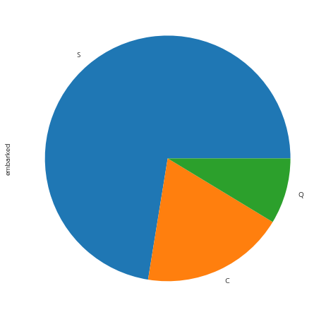

```python
em_pie=titanic['embarked'].value_counts()
em_pie.plot(kind='pie')
```

수치를 넣고 싶을 때에는 autopct 옵션을 설정합니다.

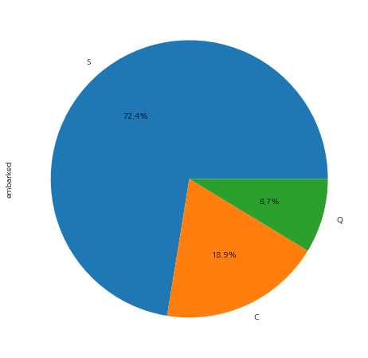

```python
em_pie.plot(kind='pie', autopct='%1.1f%%')
```

크기를 설정하고 싶을 때에는 figsize(가로, 세로) 옵션을 설정합니다.

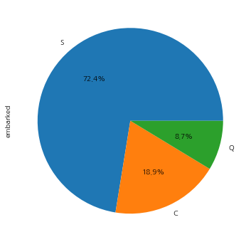

```python
em_pie.plot(kind='pie', autopct='%1.1f%%', figsize=(10,6))
```

#### 막대그래프 - countplot

countplot은 해당 컬럼의 데이터 별 갯수를 막대그래프로 표현해줍니다.

이제부터 모든 그래프는 seaborn 모듈을 활용하겠습니다.

https://seaborn.pydata.org/generated/seaborn.countplot.html

x 축에는 'embarked' 컬럼을 설정합니다. y축은 해당 컬럼내 데이터의 빈도수가 표시됩니다.

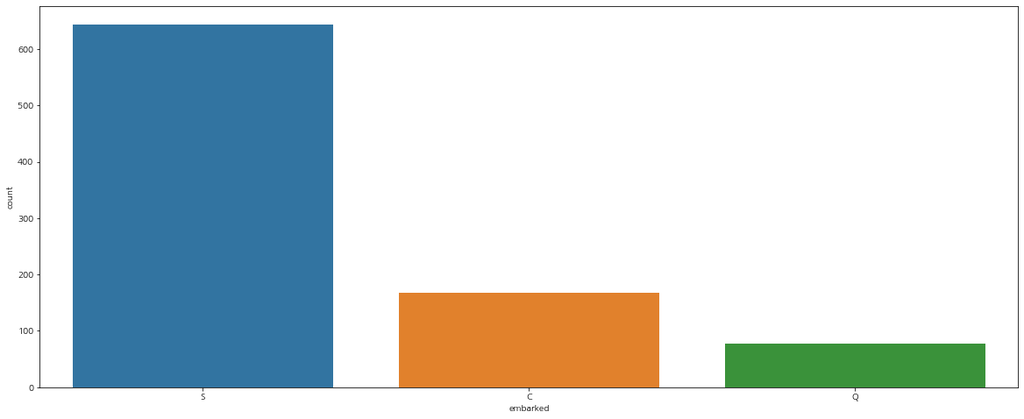

```python
sns.countplot(data=titanic, x='embarked')
```

#### 산점도 - swarmplot

swarmplot을 사용하면 데이터를 점으로 볼 수가 있습니다.

swarmplot은 x축 데이터와 y축 데이터 간의 관계를 점으로 표시합니다.

https://seaborn.pydata.org/generated/seaborn.swarmplot.html

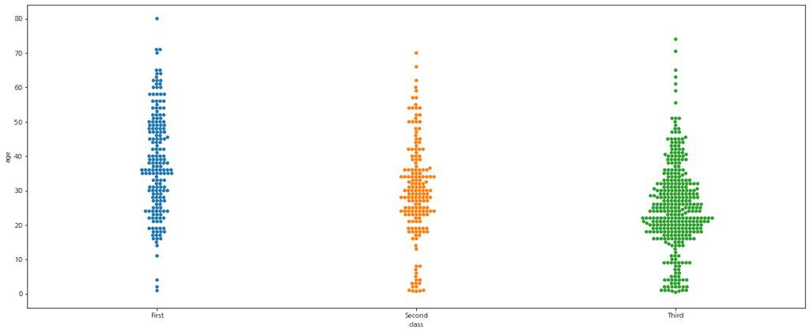

```python
sns.swarmplot(data=titanic, x='class', y='age')
```

그래프를 크기를 조정해볼까요?

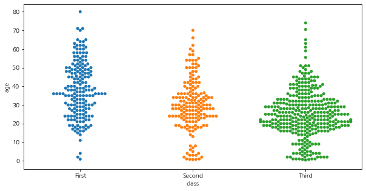

```python
plt.figure(figsize=(10,5))

sns.swarmplot(data=titanic, x='class', y='age')
```

#### 바이올린 그래프 - violinplot

violinplot을 사용하면 데이터를 도형으로 볼 수가 있습니다.

violinplot은 x축 데이터와 y축 데이터 간의 관계를 면적으로 표시합니다.

https://seaborn.pydata.org/generated/seaborn.violinplot.html

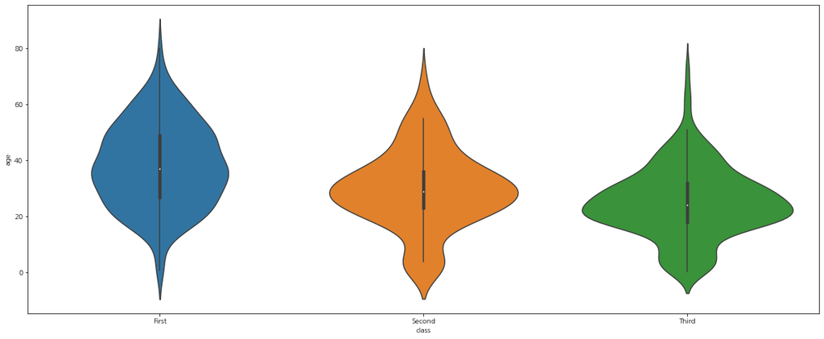

```python
sns.violinplot(data=titanic, x='class', y='age')
```

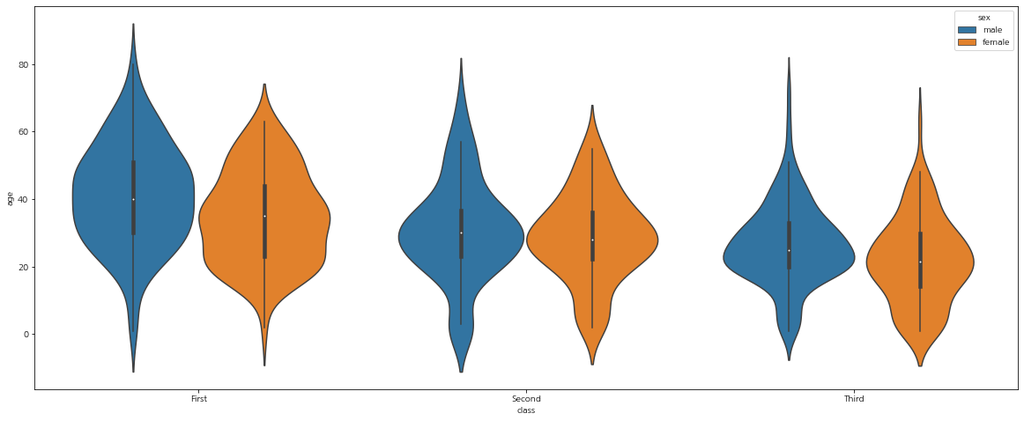

```python
sns.violinplot(data=titanic, x='class', y='age', hue='sex')
```

### 수치형 데이터

#### 대푯값

우선 데이터 전체를 대표하는 값(대푯값) 을 먼저 알아봅시다.

대푯값은 크게 평균값, 중앙값, 최빈값 이렇게 3가지가 있습니다.

1. 평균값 : 데이터의 총 합을 그 데이터의 개수로 나눈 값
2. 중앙값 : 데이터를 크기 순으로 나열 했을때 가장 중앙에 위치한 값
3. 최빈값 : 데이터 중 가장 많이 출현한 값

평균값은 가장 많이 사용하는 대푯값입니다. 그러나 데이터에 특이정(이상치)가 존재할 경우 평균값은 대푯값의 역할을 제대로 하지 못합니다.

예를 들어 각 학급의 평균키를 구하고자 할 때, 한 학급의 학생의 키가 2m가 넘는다면 그 학급의 평균키는 크게 높아질 것입니다. 2m의 키를 가진 학생을 제외한 다른 학생들의 키는 다른 학급 친구들과 별반 다를게 없는데 말이지요.

이럴 때 사용하는 것이 중앙값입니다.

우리는 데이터의 평균값, 중앙값, 최빈값을 확인하여 데이터의 특성을 파악할 수 있습니다.

#### 산포도(분산도)

산포도 - 평균 주위에서 흩어져 있는 정도를 나타냅니다.

산포도가 클수록 분포의 흩어진 폭이 넓고, 산포도가 작을수록 분포의 흩어진 폭은 좁습니다.

가장 대표적인 산포도가 분산과 표준편차입니다.

1. 분산 : 평균과 개별 데이터간 편차의 제곱의 합을 데이터의 수로 나눈 값
2. 표준편차 : 분산의 제곱근

```python
titanic.describe()
```

|  | survived | pclass | age | sibsp | parch | fare |
| --- | --- | --- | --- | --- | --- | --- |
| count | 891.000000 | 891.000000 | 714.000000 | 891.000000 | 891.000000 | 891.000000 |
| mean | 0.383838 | 2.308642 | 29.699118 | 0.523008 | 0.381594 | 32.204208 |
| std | 0.486592 | 0.836071 | 14.526497 | 1.102743 | 0.806057 | 49.693429 |
| min | 0.000000 | 1.000000 | 0.420000 | 0.000000 | 0.000000 | 0.000000 |
| 25% | 0.000000 | 2.000000 | 20.125000 | 0.000000 | 0.000000 | 7.910400 |
| 50% | 0.000000 | 3.000000 | 28.000000 | 0.000000 | 0.000000 | 14.454200 |
| 75% | 1.000000 | 3.000000 | 38.000000 | 1.000000 | 0.000000 | 31.000000 |
| max | 1.000000 | 3.000000 | 80.000000 | 8.000000 | 6.000000 | 512.329200 |

- count : 데이터의 갯수
- mean : 평균
- std : 표준편차
- min : 최솟값
- 25% : 제1사분위수(크기 하위부터 25%)
- 50% : 제2사분위수(크기 하위부터 50%)
- 75% : 제3사분위수(크기 하위부터 75%)
- max : 최댓값

#### 막대그래프 - barplot

barplot은 x축 데이터와 y축 데이터 간의 관계를 막대그래프로 표현해줍니다.

https://seaborn.pydata.org/generated/seaborn.barplot.html

X축에는 'sex'컬럼 데이터, Y축에는 'sex'컬럼 데이터에 매칭하는 'survived'컬럼 값들의 평균값을 보여줍니다.

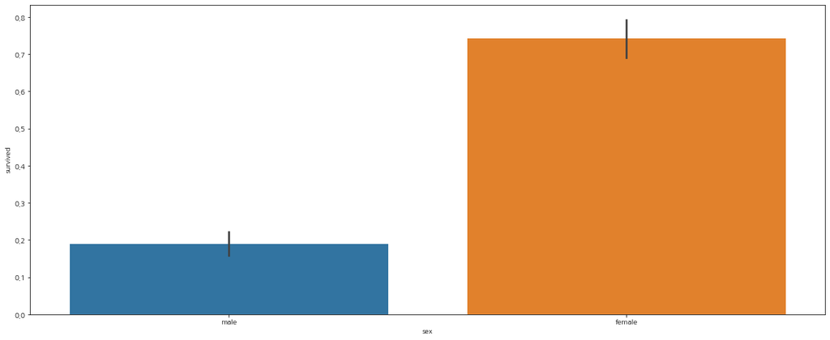

```python
sns.barplot(data=titanic, x='sex', y='survived')
```

hue 옵션을 'class'로 설정해주면 좌석등급에 따른 차이를 알 수 있습니다.

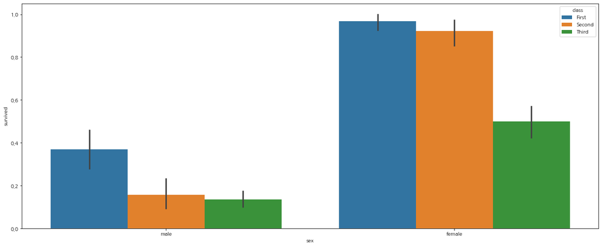

```python
sns.barplot(data=titanic, x='sex', y='survived', hue='class')
```

#### 꺾은선 그래프 - pointplot

pointplot은 x축 데이터와 y축 데이터 간의 관계를 꺾은선으로 표현해줍니다.

https://seaborn.pydata.org/generated/seaborn.pointplot.html

위에서 활용했던 titanic 데이터셋을 가지고 살펴봅시다.

X축에는 'sibsp'컬럼 데이터, Y축에는 'sibsp'컬럼 데이터에 매칭하는 'survived'컬럼 값들의 평균값을 선으로 보여줍니다.

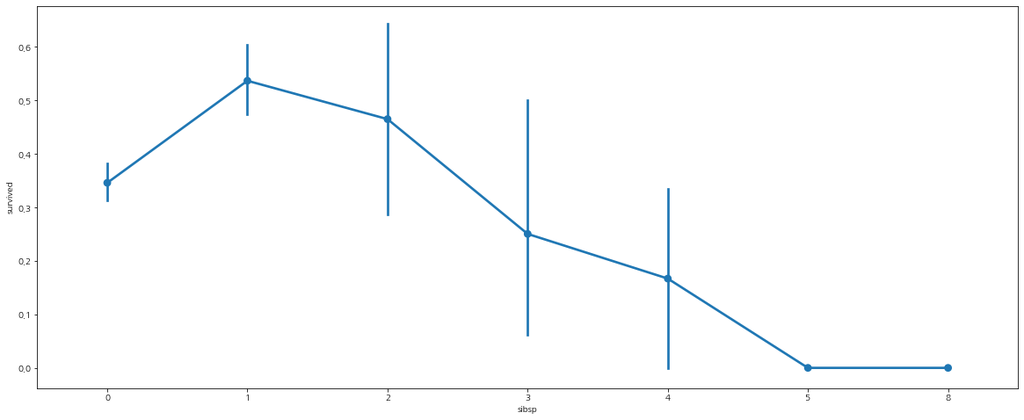

```python
sns.pointplot(data=titanic, x='sibsp', y='survived')
```

hue 옵션을 'sex'로 설정하면 sex별 데이터를 확인할 수 있습니다

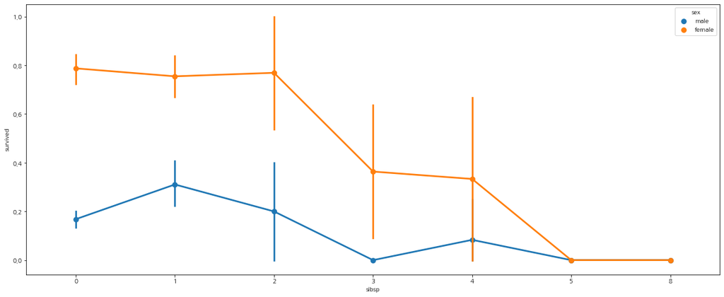

```python
sns.pointplot(data=titanic, x='sibsp', y='survived', hue='sex')
```

#### 산점도 - scatterplot

scatterplot은 x축 데이터와 y축 데이터 간의 관계를 점으로 표현합니다.

https://seaborn.pydata.org/generated/seaborn.scatterplot.html

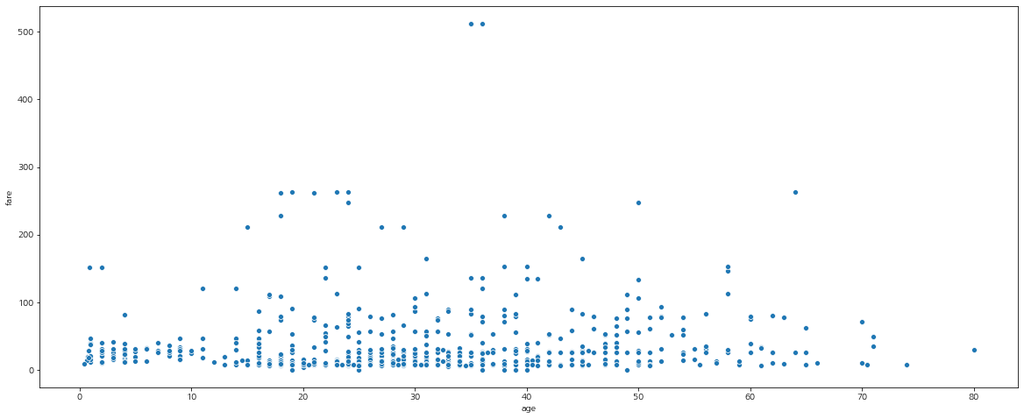

```python
sns.scatterplot(data=titanic, x='age', y='fare')
```

hue 옵션을 'sex'로 설정하면 sex별 데이터를 확인할 수 있습니다

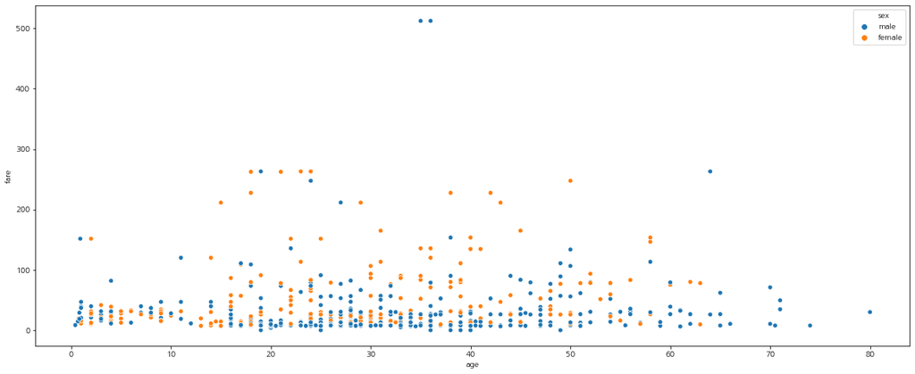

```python
sns.scatterplot(data=titanic, x='age', y='fare', hue='sex')
```

#### 회귀선이 있는 산점도 - lmplot

lmplot은 x축 데이터와 y축 데이터 간의 관계를 점으로 표시하고 회귀선을 보여줍니다.

https://seaborn.pydata.org/generated/seaborn.lmplot.html

X축에는 'age'컬럼 데이터, Y축에는 'age'컬럼 데이터에 매칭하는 'fare'컬럼 값들을 점으로 보여줍니다. 회귀선을 볼 수 있습니다.

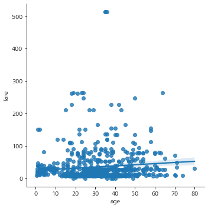

```python
sns.lmplot(data=titanic, x='age', y='fare')
```

fit_reg=False 옵션을 설정하면 회귀선을 안보이게 할 수 있습니다.

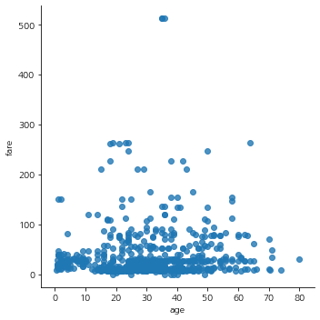

```python
sns.lmplot(data=titanic, x='age', y='fare', fit_reg=False)
```

hue 옵션을 'sex'로 설정하면 sex별 데이터를 확인할 수 있습니다

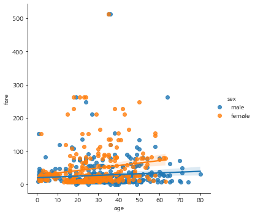

```python
sns.lmplot(data=titanic, x='age', y='fare', hue='sex')
```

#### 상자 그래프 - boxplot

box plot은 데이터의 분포를 직관적으로 확인하기 쉽게 보여줍니다.

https://seaborn.pydata.org/generated/seaborn.boxplot.html

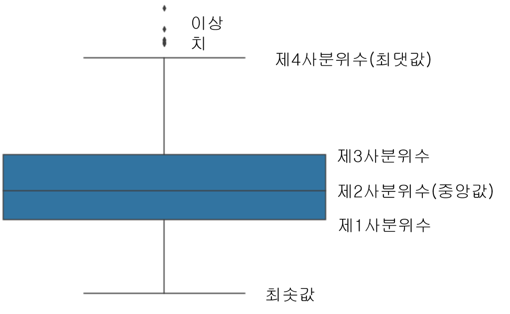

이상치 : (제1사분위수 - 1.5 *사분위 범위) ~ (제3사분위수 + 1.5* 사분위 범위) 에 해당하지 않는 값

※ 사분위 범위 : 제3사분위수-제1사분위수

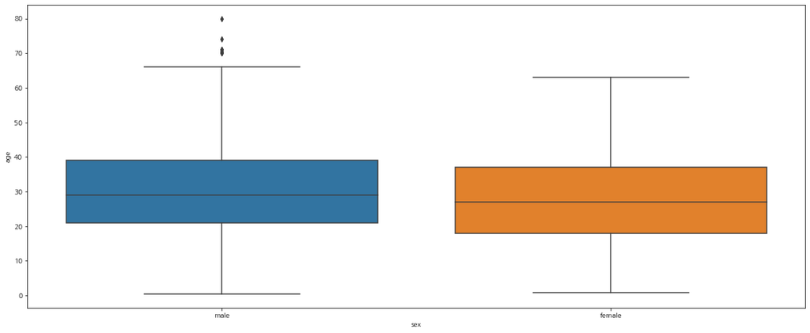

```python
sns.boxplot(data=titanic, x='sex', y='age')
```

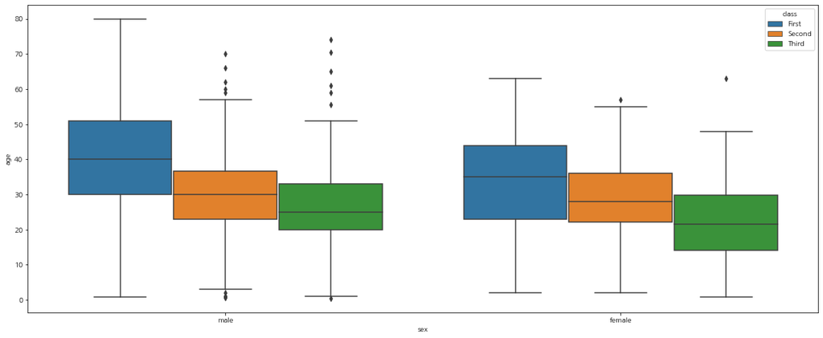

```python
sns.boxplot(data=titanic, x='sex', y='age', hue='class')
```

#### 복수의 그래프 - FacetGrid

FacetGrid은 데이터 값에 따라 표현되는 복수의 그래프를 보여줍니다.

https://seaborn.pydata.org/generated/seaborn.FacetGrid.html

행과 열로 구분할 컬럼을 설정합니다.

plt.hist으로 옵션을 설정하면 히스토그램으로 표시됩니다.

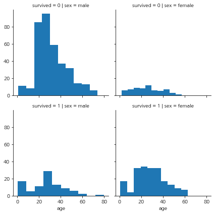

```python
g=sns.FacetGrid(data=titanic, col='sex', row='survived')
g.map(plt.hist, 'age')
```

plt.scatter으로 옵션을 설정하면 산점도로 표시됩니다.

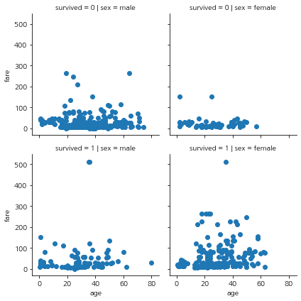

```python
g=sns.FacetGrid(data=titanic, col='sex', row='survived')
g.map(plt.scatter, 'age', 'fare')
```

#### 히스토그램/커널밀도 그래프

distplot은 히스토그램과 커널 밀도 함수를 그래프로 보여줍니다.

- 히스토그램 : 데이터를 계급으로 나누어 그에 해당하는 도수를 나타낸 표
- 커널 밀도 : 그래프와 x축 사이의 면적이 1이 되도록 그리는 밀도 분포

https://seaborn.pydata.org/generated/seaborn.distplot.html

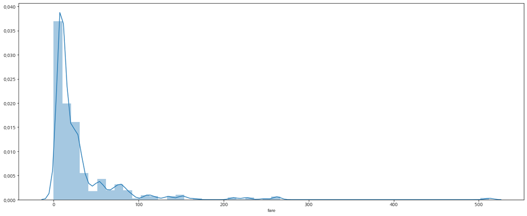

```python
sns.distplot(titanic['fare'])
```

커널 밀도 그래프만 보고 싶으면 hist=False 옵션을 설정합니다.

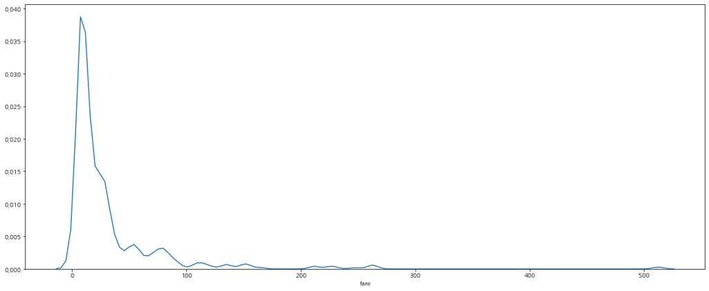

```python
sns.distplot(titanic['fare'], hist=False)
```

히스토그램만 보고 싶으면 kde=False 옵션을 설정합니다.

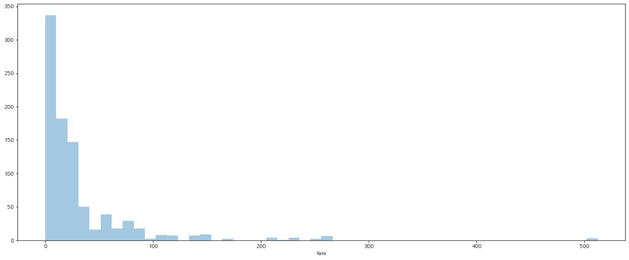

```python
sns.distplot(titanic['fare'], kde=False)
```

#### 데이터 간의 상관관계

데이터 간의 상관관계를 표현해주는 가장 대표적인 지수가 피어슨(pearson) 상관계수입니다.

피어슨 상관계수는 두 변수 간 상관 관계를 나타내는데,

상관계수의 크기가 0에 가까울수록 관련성이 낮고, 1에 가까울수록 관련성이 높다고 볼 수 있습니다.

기준을 세분화해보면 0에서 0.1은 관련성이 거의 없습니다. 0.1부터 0.3의 상관계수는 약한 관련성이 있고, 0.3부터 0.7까지는 어느 정도 관련성이 있다고 판단할 수 있습니다. 만일 상관계수가 정도가 0.7부터 1 사이라면, 관련성이 강하다고 볼 수 있습니다.

양수와 음수는 비례와 반비례를 나타냅니다. 만일 변수 X와 Y의 상관계수가 0 이상이라면 양의 상관관계를 보입니다. 즉, X가 증가한다면 Y도 증가합니다. 반면 X와 Y의 상관계수가 0보다 작다면 반비례의 관계를 보이게 됩니다. X가 증가하면, Y는 감소합니다.

corr() 함수를 활용하면 각 변수들의 피어슨 상관계수를 확인 할 수 있습니다.

https://pandas.pydata.org/pandas-docs/stable/reference/api/pandas.DataFrame.corr.html

```python
titanic.corr()
```

|  | survived | pclass | age | sibsp | parch | fare | adult_male | alone |
| --- | --- | --- | --- | --- | --- | --- | --- | --- |
| survived | 1.000000 | -0.338481 | -0.077221 | -0.035322 | 0.081629 | 0.257307 | -0.557080 | -0.203367 |
| pclass | -0.338481 | 1.000000 | -0.369226 | 0.083081 | 0.018443 | -0.549500 | 0.094035 | 0.135207 |
| age | -0.077221 | -0.369226 | 1.000000 | -0.308247 | -0.189119 | 0.096067 | 0.280328 | 0.198270 |
| sibsp | -0.035322 | 0.083081 | -0.308247 | 1.000000 | 0.414838 | 0.159651 | -0.253586 | -0.584471 |
| parch | 0.081629 | 0.018443 | -0.189119 | 0.414838 | 1.000000 | 0.216225 | -0.349943 | -0.583398 |
| fare | 0.257307 | -0.549500 | 0.096067 | 0.159651 | 0.216225 | 1.000000 | -0.182024 | -0.271832 |
| adult_male | -0.557080 | 0.094035 | 0.280328 | -0.253586 | -0.349943 | -0.182024 | 1.000000 | 0.404744 |
| alone | -0.203367 | 0.135207 | 0.198270 | -0.584471 | -0.583398 | -0.271832 | 0.404744 | 1.000000 |

#### 상관관계 그래프 - heatmap

heatmap은 데이터 간의 상관계수를 색깔로 표시해줍니다.

https://seaborn.pydata.org/generated/seaborn.heatmap.html

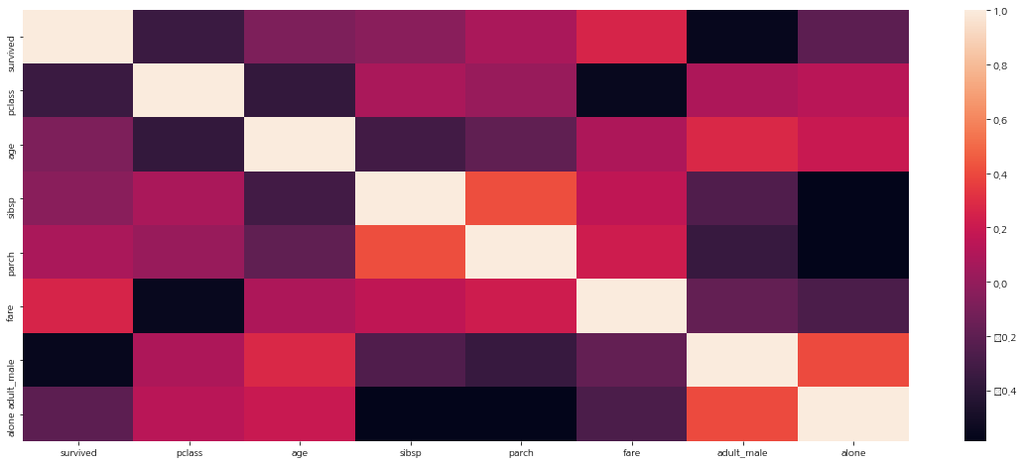

```python
sns.heatmap(titanic.corr())
```

#### 정규분포

정규분포는 확률분포 중 가장 많이 사용되는 분포입니다.

정규준포는 평균을 기준으로 좌우대칭이며 평균값이 최댓값이 됩니다.

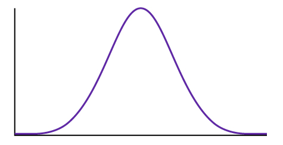

신기하게도 대부분의 데이터의 분포는 정규분포와 근사합니다.

(수학적으로 증명이되었다고 하네요..)

우리는 이러한 정규분포의 특성을 가지고 데이터분석에 활용할 수 있습니다.

Fare 컬럼을 distplot으로 표현하면 다음과 같습니다.

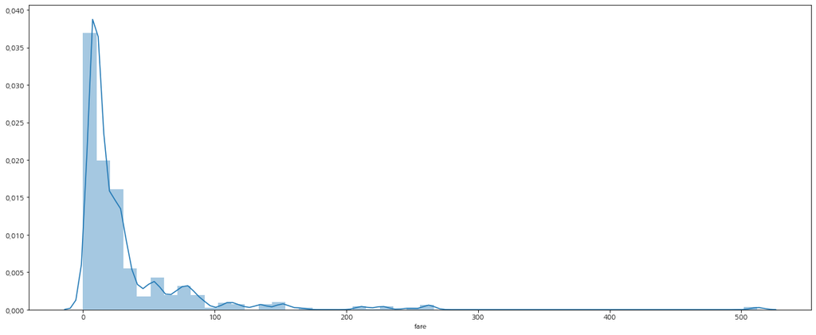

```python
sns.distplot(titanic['fare'])
```

정규분포와는 거리가 머네요..

Fare 컬럼의 데이터에 로그를 씌우서 정규화시킬 수 있습니다.

◎ 로그 연습

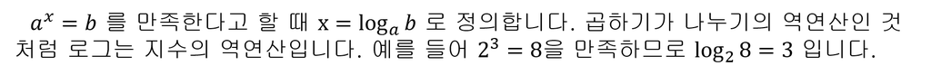

※ 넘파이 (numpy)

넘파이는 머신러닝에서 사용하는 벡터, 행렬을 표현하고 연산할 때 사용하는 파이썬 라이브러리입니다.

머신러닝을 하기 위해서는 넘파이를 꼭 짚고 넘어가야 하나

이번 과정에서는 머신러닝을 다루지 않으므로 로그함수를 활용하기 위해서 넘파이 모듈을 사용하도록 하겠습니다.

```python
import numpy as np
```

```python
# log1p : log(1+x)
# (1+x)로 하는 이유: 로그데이터에 0이 들어가면 -무한대로 발산해서 오류가 날 수 있기 때문입니다.

titanic['fare_log']=np.log1p(titanic['fare'])
```

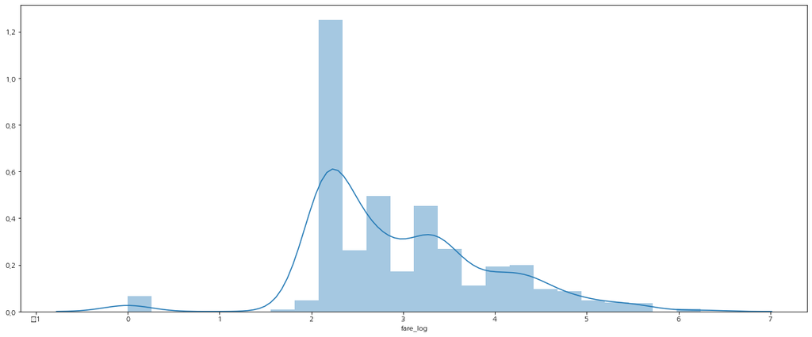

```python
sns.distplot(titanic['fare_log'])
```

distplot을 그려보면 로그를 씌웠을 때 정규분포에 근사함을 확인할 수 있습니다.

정규분포로 근사시켰을 때 다음과 같은 장점이 있습니다.

1. 기존 데이터의 비대칭적인 상황보다 더 정확한 대푯값을 찾을 수 있습니다.
2. 특이점(이상치)나 문제가 되는 포인트를 찾기가 쉽다.

■ 1. 기존 데이터의 비대칭적인 상황보다 더 정확한 대푯값을 찾을 수 있습니다.

이것을 찾아보기 위해 fare_log 컬럼의 통계적 수치를 살펴보겠습니다.

```python
titanic['fare_log'].describe()
```

```
count    891.000000
mean       2.962246
std        0.969048
min        0.000000
25%        2.187218
50%        2.737881
75%        3.465736
max        6.240917
Name: fare_log, dtype: float64
```

```python
# expm1 : 지수화

np.expm1(titanic['fare_log'].describe())
```

```
count           inf
mean      18.341359
std        1.635435
min        0.000000
25%        7.910388
50%       14.454200
75%       31.000000
max      512.329200
Name: fare_log, dtype: float64
```

```python
titanic['fare'].describe()
```

```
count    891.000000
mean      32.204208
std       49.693429
min        0.000000
25%        7.910400
50%       14.454200
75%       31.000000
max      512.329200
Name: fare, dtype: float64
```

정규화 시킨 후 구한 'fare' 데이터의 평균과 표준편차가 raw data에서 구한 평균과 표준편차에 차이가 있음을 확인할 수 있습니다.

(※ raw data : 미가공된 원시 데이터)

■ 2. 특이점(이상치)나 문제가 되는 포인트를 찾기가 쉽다.

값이 0인 데이터가 꽤 많이 존재함을 알 수 있습니다.

이 역시 기존의 그래프에서는 찾기 힘든 부분입니다.

```python
titanic.corr()
```

|  | survived | pclass | age | sibsp | parch | fare | adult_male | alone | fare_log |
| --- | --- | --- | --- | --- | --- | --- | --- | --- | --- |
| survived | 1.000000 | -0.338481 | -0.077221 | -0.035322 | 0.081629 | 0.257307 | -0.557080 | -0.203367 | 0.329862 |
| pclass | -0.338481 | 1.000000 | -0.369226 | 0.083081 | 0.018443 | -0.549500 | 0.094035 | 0.135207 | -0.661022 |
| age | -0.077221 | -0.369226 | 1.000000 | -0.308247 | -0.189119 | 0.096067 | 0.280328 | 0.198270 | 0.116495 |
| sibsp | -0.035322 | 0.083081 | -0.308247 | 1.000000 | 0.414838 | 0.159651 | -0.253586 | -0.584471 | 0.318528 |
| parch | 0.081629 | 0.018443 | -0.189119 | 0.414838 | 1.000000 | 0.216225 | -0.349943 | -0.583398 | 0.332186 |
| fare | 0.257307 | -0.549500 | 0.096067 | 0.159651 | 0.216225 | 1.000000 | -0.182024 | -0.271832 | 0.787543 |
| adult_male | -0.557080 | 0.094035 | 0.280328 | -0.253586 | -0.349943 | -0.182024 | 1.000000 | 0.404744 | -0.295684 |
| alone | -0.203367 | 0.135207 | 0.198270 | -0.584471 | -0.583398 | -0.271832 | 0.404744 | 1.000000 | -0.478410 |
| fare_log | 0.329862 | -0.661022 | 0.116495 | 0.318528 | 0.332186 | 0.787543 | -0.295684 | -0.478410 | 1.000000 |

fare_log와 다른 컬럼간의 상관관계를 보면 fare보다 대체적으로 수치가 상승하는 것을 볼 수 있습니다.

fare는 우리가 생각했던 것 보다 더 생존확률과 상관관계가 높음을 알 수 있습니다.